# Phuong_VCB_Model_Validation_Ver2-Copy2

$$\Large \underline{\color{red}{\textbf{BÁO CÁO THỰC HIỆN}}}$$$$\Large \color{blue}{\textbf{Giới Thiệu Cách Thức Tính Toán Và Áp Dụng Hơn 35 Chỉ Tiêu }}$$$$\Large \color{blue}{\textbf{Và Phương Pháp Theo Chuẩn Mực Quốc Tê Được Sử Dụng }}$$$$\Large \color{blue}{\textbf{Cho Qúa Trình Phân Tích Độ Nhạy Trong Việc Đánh Gía }}$$$$\Large \color{blue}{\textbf{Và Giám Sát Hoạt Động Của Mô Hình Dự Báo Rủi Ro Vỡ Nợ}}$$$$\Large \color{blue}{\textbf{Trong Hoạt Động Tín Dụng Của Ngân Hàng}}$$$$\small \color{green}{\textbf{Đức, Ngày 20 Tháng 03 Năm 2020}}$$$$\small \color{green}{\textbf{Người thực hiện}}$$$$\large \color{green}{\textbf{NCS. Phuong Van Nguyen}}$$$$\small \color{red}{\textbf{ phuong.nguyen@summer.barcelonagse.eu}}$$$$\small \color{red}{\textbf{ phuong.nguyen@economics.uni-kiel.de}}$$$$\small \color{red}{\textbf{ phuongnv@iuj.ac.jp}}$$

$\underline{\color{blue}{\textbf{I. Giới Thiệu}}}$

$\underline{\color{blue}{\textbf{1. Động Cơ Và Mục Tiêu Của Dự Án}}}$

Vào tháng 6/2004, Uỷ Ban Basel về Giám Sát Hoạt Động Ngân Hàng đã phát hành phiên bản sửa đổi cho Basel II về Quy Chuẩn Quốc Tế Chung Cho Đo Lường và Tiêu Chuẩn Vốn (International Convergence of Capital Measurement and Capital Standards). Theo đó, các Ngân hàng và Tổ Chức Tín Dụng được phép sử dụng các Mô Hình nội bộ của họ cho kiểm soát tín dụng để đảm bảo những yêu cầu tối thiểu về vốn. Trước những yêu cầu đó, rõ ràng là việc phát triển các phương pháp để phân tích độ nhạy cho việc kiểm định và giám sát các Mô hình Xếp Hạng Tín Dụng Nội Bộ (IRB) trở lên vô cùng quan trọng, trong việc đảm bảo hoạt động ngân hàng theo tiêu chuẩn của Basel II.

Hoạt động hiệu của Mô Hình Xếp Hạng Tín Dụng Nội Bộ (IRB), là tiền để để ngân hàng tính toán được các chỉ tiêu quan trọng cho kiểm soát rủi ro tín dụng, như

- Probability of Default (PD): Xác xuất Vỡ Nợ.
- Loss Given Default (LGD): Khoản Lỗ Sau Khi Xử Lý Nợ, như bằng cách bán Nợ, Trong Tình Huống Vỡ Nợ Xảy Ra (.
- Exposure At Default (EAD): Tổng Khoản Lỗ Trong Tình Huống Vỡ Nợ Xảy Ra.
- Expected Loss: Khoản Lỗ Kỳ Vọng Nếu Xả Ra Vỡ Nợ (Expected Loss=PD*LGD*EAD)

Chính vì vậy, trong dự án này, mục tiêu chính của chúng tôi đó là trên cơ sở $\textbf{Khuyến Nghị của Uỷ Ban Basel II về giám sát Hoạt động Ngân hàng}$ và thực hành tại hệ thống Ngân hàng trên thé giới như ECB, Deutsche Bundesbank, Moody, Deloite, etc, các Tài Liệu Thống Kê, Toán Kinh Tế Lượng, chúng tôi

$$\color{green}{\textbf{Giới thiệu trên 35 công cụ và chỉ tiêu thống kê}}$$

được sử dụng cho $\textbf{phân tích Độ Nhạy trong quá trình kiểm định và giám sát hoạt động}$ của Mô hình Xếp Hạng Tín Dụng Nội Bộ, cụ thể ở đây là Mô Hình Logistic.

Mặc dù theo khuyến nghị của Uỷ Ban Basel (Basel Accords II) thì chỉ cần hai chỉ tiêu

1. Accuracy Ratio
2. Receiver Operating Characteristic

là đủ để phân tích Độ Nhạy cho Kiểm định và giám sát Mô Hình nội bộ. Tuy nhiên, vì khuyến nghị của Ủy Ban Basel không phải là yêu cầu bắt buộc với tất cả các Hệ Thống Ngân hàng trên toàn thế giới, mà nó chỉ mang tính tham khảo. Do đó, trong Dự Án này chúng tôi không đưa ra kết luận cụ thể công cụ thể hay chỉ tiêu nào tốt nhất để Phân tích độ nhạy cho việc kiểm định và giám sát Mô Hình Logistic. Thực tế là khi chúng tôi tham khảo các chỉ tiêu, phương pháp Phân tích độ nhạy cho việc Kiểm định và giám sát Mô Hình nội bộ của các Ngân Hàng Trung Ương(NHTW) trên Thế Giới, như ECB, NHTW Đức (Deutsche Bundesbank), NHTW Ba Lan, NHTW Bồ Đảo Nha, một loạt các định chế tài chính, như Moody, Deloite, etc. thì đều có những cách tiếp cận khác dựa trên cơ sở khuyến Nghị của Basel II.

Thêm nữa, cũng chính Uỷ Ban Basel II, trong tài liệu $\textbf{"Studies on the Validation of Internal Rating System, Working Paper No.14, Revisied Version, May 2005"}$, tại trang 29, họ ghi như sau:

$$\small \color{red}{\text{"The choice of a specific technique to be applied for validation should depend upon the nature of the portfolio }}$$$$\small \color{red}{\text{under consideration. Retail portfolios or portfolios of small- and medium-sized enterprises with large records }}$$$$\small \color{red}{\text{of default data are much easier to explore with statistical methods than, for example,portfolios of sovereigns}}$$

$$\small \color{red}{\text{or financial institutions where default data are sparse."}}$$

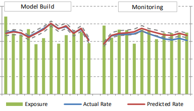

$$\text{Nguồn: https://www.finity.com.au/}$$

$\underline{\color{blue}{\textbf{2. Hạn Chế của Dự Án}}}$

Mặc dù Phân tích độ nhạy cho việc kiểm định và giám sát mô hình là quan trọng. Tuy nhiên, đây không phải là bước duy nhất trong việc đảm bảo mô hình hoạt động hiệu quả. Các vần đề quan trọng khác liên quan tới phát triên mô hình, chúng tôi sẽ không đề cập trong dự án này, sẽ liệt kê ra ở dưới đây

- Thứ nhất, liên quan tới dữ liệu, cũng là một vấn đề $\textbf{then chốt}$ đảm bảo chất lượng của mô hình. Cụ thể hơn, nếu dữ liệu đầu vào bị $\textbf{mất cân đối}$ và không được xử lý bằng các kỹ thuật như: Over-sampling, Under-sampling, và Synthetic Minority Oversampling Technique (SMOTE), trước khi đào tạo mô hình, thì $\textbf{chắc chắn rằng}$ mô hình tạo ra sẽ hoạt động không hiểu quả. Và vấn đề $\textbf{mất cân đối}$ dữ liệu lại là vấn đề $\textbf{Phổ biến}$ trong bài toán thực tế. Ví dụ như, số lượng khách hàng Vỡ nợ sẽ $\textbf{luôn luôn}$ là ít hơn số lượng khác hàng không vỡ nợ
- Thứ hai, trong dữ liệu thô thực tế, có tới hàng trăm các biến số liên quan tới hoạt động tín dụng trong ngân hàng. Vậy chúng ta có nên đưa hết tất cả các biến đó vào trong mô hình? Hay làm thế nào để chọn biến vào mô hình? Để làm việc này, một trong những Thuật Toán chúng ta có thể áp dụng đó là Principal Component Analysis (PCA). Do đó, nếu bước này chúng ta không làm tốt thì $\textbf{chắc chắn rằng}$ mô hình tạo ra sẽ hoạt động không hiểu quả, etc.
- Thứ ba, Mô hình Logistic $\textbf{chắc chắn là}$ chưa phải một mô hình tối ưu nhất trong giải quyết bài toán dự báo rủi ro vỡ nợ trong hoạt động ngân hàng. Còn rất nhiều Mô hình và đặc biệt các chương trình Máy Học hoặc Deep Learning sử dụng các thuật toán hiện đại, có khả năng dự báo $\textbf{tốt hơn}$ rất nhiều Mô hình Logistic, chẳng hạn như Extreme Gradient Boosting, Long Short-Term Memory (LSTM), etc
- etc..

Nhờ có được các chương trình học bổng toàn phần từ IMF, Graduate School Scholarship Program (GSSP), quý DAAD Research Allowance, mà chúng tôi đã có được sự đào tạo bài bản về chuyên môn ở các cấp độ Ths và TS ở các quốc gia tiên tiến: Nhật Bản, Đức và các chương trình ngắn hạng ở Châu Âu, kết hợp với kinh nghiệm thời làm việc tại Phòng Mô Hình Hóa, Ngân Hàng Trung Ương Thụy Điển (Sveriges Riksbank), nếu được Qúy Ngân hàng trao cơ hội, chúng tôi hoàn toàn tự tin giải quyết được tất cả các vấn đề đã nêu ra ở trên và các yêu cầu khác của VCB.

$\underline{\color{blue}{\textbf{3. Dữ Liệu}}}$

Để thực, hiện Dự An này, chúng tôi sử dụng dữ liệu về Vỡ Nợ của thẻ tín dụng, tại Kho Dữ Liệu của Trung Tâm Nghiên cứu Máy Học và Trí Tuệ Thông Minh Nhân Tạo thuộc Đại Học California, Irvine. Chi tiết về dữ liệu và tải dữ liệu có thể tải tại đường dẫn dưới đây.

https://archive.ics.uci.edu/ml/datasets/default+of+credit+card+clients

$\underline{\color{blue}{\textbf{4. Phương Thức Thực Hiện}}}$

- Thứ nhất, Theo như khuyến nghị của Uỷ Ban Basel, cũng như các kỹ thuật trong Máy Học, chúng tôi tiến hành Phân tích Độ Nhạy cho kiểm định và giám sát Mô hình ở cả mảng In-Sample và cả Out-Of-Sample. Trong đó, phần $\color{blue}{\textbf{Out-of-sample}}$ sẽ được coi như phần giám sát mô hình $\color{blue}{\textbf{(Model Monitoring)}}$ . Để làm điều đó, chúng tôi chia dữ liệu theo tỷ lệ phân chia 70/30. Chú ý rằng, thông thường việc chia này phải được thực hiện một cách ngẫu nhiên $\textbf{random split}$, tuy nhiên trong tình huống này, để đơn giản, chúng tôi sẽ lấy 21000 quan sát đầu tiên trong bộ dữ liệu để đào tạo mô hình, và số còn lại là để giám sát mô hình.

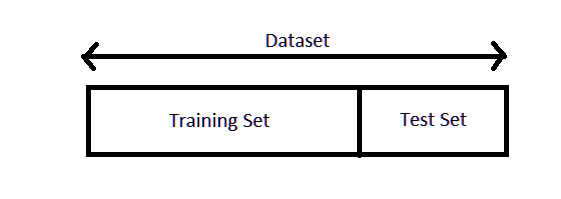

- Thứ hai, quá trinh thực nghiệm Dự Án, chúng tôi sử dụng Ngôn Ngữ Lập Trình Python. Ngoài ra, chúng tôi hoàn toàn có thể phân tích thực nghiệm dự án này bằng các ngôn ngữ máy tính khác như R hay Matlab theo yêu cầu của Qúy Phòng.

$\underline{\color{blue}{\textbf{5. Kết quả dự án và Khuyến Nghị}}}$

1. $\textbf{Kết quả}$: Trong thời gian 1 tuần nghiên cứu và thực hiện, chúng tôi đã hoàn thành giới thiệu cách tính toán của hơn $\underline{\color{blue}{\textbf{35 chỉ tiêu}}}$ phục vụ cho quá trình phân tích độ nhạy trong kiểm định và giám sát hoạt động của Mô Hình Logistic nói riêng, và các Mô hình Xếp Hạng Tín Dụng Nội Bộ (IRB) nói chung. Kết quả đạt được đó là, Dự án này đã giới thiệu và trình bày cách tính toán tất cả các chỉ tiêu, phương thức không chỉ theo khuyến nghị của Uỷ Ban Basel (Basel II) mà còn của các Hệ Thống Ngân hàng, các tổ chức tài chính trên thế giới.
1. $\textbf{Khuyến nghị}$:Phát triển mô hình đánh giá rủi ro đóng vai trò tối quan trọng trong hoạt động ngân hàng. Các mô hình kinh tế lượng với phương pháp tiếp cận truyền thống (frequentist) như OLS, Maximum Likelihood, hiện tại đã thể hiện những bất cập trong ước lượng hệ số mô hình, cụ thể giá trị P-value không còn tin tưởng sử dụng để đánh giá mô hình. Thay thế khuyến điểm đó, Bayesian econometrics được sử dụng rổng rãi hơn. Tuy nhiên, góc độ Industry thì Chương Trình Máy Học/AI đang được sử dụng rộng rãi trong mọi mặt của đời sống, trong đó Logistic chỉ là một Thuật toán trong nhiều Thuật toán được sử dụng để "Dạy khôn" chúng. Do đó, qua đề tài này chúng tôi muốn đưa ra khuyến nghị là phát triển các chương trình Máy Học/AI để dự báo rủi ro trong hoạt động ngân hàng. Dựa vào bộ dự liệu trong dự án này, chúng tôi có thể phát triển chương trình máy học, có khả năng dự báo chính xác rủi ro Vỡ Nợ của Ngân hàng với $\textbf{độ chính xác rất vượt}$ trội so với Mô hình Logistic. Tuy nhiên, do yêu cầu của dự án nên chúng tôi không giới thiệu việc phát triển Máy Học/AI mà tập trung đi xâu vào góc độ Phân Tích Độ Nhạy của mô hình Logistic. Hy vọng, sẽ có cơ hội phát triển xây dựng một chương trình Máy Học/AI trong dự báo rủi ro tín dụng trong hoạt động Ngân hàng tại Qúy Phòng.

$\underline{\color{blue}{\textbf{6. Tài Liệu Tham Khảo}}}$

Trong quá trình thực hiện Dự An Phân Tích Độ Nhạy của Mô Hình Logistic, chúng tôi đã tham khảo rất nhiều nguồn từ Industry cũng như trong Academic. Từ đó, chúng tôi nhận thấy rằng khái niệm này là rất rộng. Tuy nhiên, để tránh tình trạng lang man, không có một hướng đi cụ thể rõ ràng cho Phân Tích Độ Nhạy (Sensitivity Analysis), thì chúng tôi tiến hành tập hợp và tổng hợp để chọn ra một cách tiệm cận cho hướng đi của Dự án này. Cụ thể, tiêu chí lựa chọn của chúng tôi đó là lọc ra những khái niệm có tính chất chung và tổng quát nhất về Phân Tích Độ Nhạy (Sensitivity Analysis) sử dụng cho giám sát và kiểm định Mô Hình.

Ví dụ, liên quan tới Banking Industry, Chúng Tôi đặc biệt chú ý tới những Khuyến Nghị của Uỷ Ban Basel Về Giám Sát Hoạt Động Ngân hàng (Basel II). Cụ thể, đó là Tài Liệu, $\textbf{"Studies on the Validation of Internal Rating Systems" Revised Version, May 2005}$. Lý do chính chúng tôi sử dụng Khuyến Nghị của Uỷ Ban Basel, bởi đây là những khuyến nghị chuẩn dành cho tất cả các Ngân hàng trên toàn thế giới, trong việc phân tích đánh giá và giám sát các mô hình phân loại rủi ro nội bộ trong mỗi ngân hàng. Mặc dù, hiện tại sau Khủng Hoảng tài chính 2008, hiện nay Basel III đã được triển khai. Tuy nhiên, do hệ thống Ngân hàng Việt Nam vẫn đang triển khai hoạt động giám sát ngân hàng theo khuyến Nghị của Basel II, cho nên trong dự án này chúng tôi đặc biệt xây dựng và giới thiệu quy trình các chỉ tiểu sử dụng cho phân tích độ nhạy trong kiểm định và giám sát Mô hình Logistic của VCB. Thêm vào đó, việc áp dụng của Uỷ Ban Basel chỉ mang tính tham khảo, không có tính bắt buộc với hệ thống Ngân hàng trên toàn thế giới. Do đó, ngoài việc sử dụng những Khuyến Nghị của Uỷ Ban Basel, trong dự án này chúng tôi cũng tham khảo hoạt động Phân tích Độ nhạy cho việc Đánh giá và giám sát mô hình nội bổ của các quốc gia trên thế giới, như Ngân hàng Trung ương (NHTW) Châu Âu (ECB), NHTW Đức (Deutsche Bundesbank), etc và các công ty tài chính trên thế giới như Moody, Deloite, etc

1. Basel Committee on Banking Supervision. Studies on the Validation of Internal Rating Systems. Working Paper No. 14, Revised version, May 2005.
2. Natalia Nehrebecka. Approach to the assessment of credit risk for non-financial corporations. Poland Evidence
3. Bernd Engelmann, Evelyn Hayden, Dirk Tasche. Measuring the Discriminative Power of Rating Systems. Discussion paper Series 2: Banking and Financial Supervision No 01/2003.
4. Bernd Engelmann, Robert Rauhmeier. The Basel II Risk Parameters: Estimation, Validation Testing with Application to Loan Risk Management. Second Edition, Springer.
5. Stefan Blochwitz, Thilo Liebig, Mikael Nyberg. Benchmarking Deutsche Bundesbank’s Default Risk Model, the KMV@ Private Firm Model@ and Common Financial Ratios for German Corporations. 2000
6. Audrey Mauguen and Colin B. Begg. Using the Lorenz Curve to Characterize Risk Predictiveness and Etiologic Heterogeneity
7. Mark Goldburd, Anand Khare, Dan Tevet, Dmitriy Guller. GENERALIZED LINEAR MODELS FOR INSURANCE RATING. Second Edition
8. Michael J. Budinger; Ryan A. Michalik. Credit risk rating model validation: getting full value from an important process.
9. Moody's Analytics. Model Monitoring: Independence, Speed and Accuracy.
10. John Yick, Michael McLaon. To Freak Out or to Chill Out? A Guide to Model Monitoring. Finity Personal Lines Pricing And Portfolio Management Seminar, 2014.
11. Accenture. Credit Risk Model Monitoring.
12. Saltelli, A.; Ratto, M.; Andres, T.; Campolongo, F.; Cariboni, J.; Gatelli, D.; Saisana, M.; Tarantola, S. (2008). Global Sensitivity Analysis: The Primer. John Wiley & Sons.
1. Saltelli, A.; Ratto, M.; Campolongo, F.; Cariboni, J.; Gatelli, D.; Saisana, M.; Tarantola, S. (2008). Sensitivity Analysis In Practice: A Guide to Scientist Models.
1. Jeffrey M.Wooddridge. Introductory Econometrics: A Modern Approach, 2013.
2. Ruey S.Tsay. Analysis of Financial Time Series.
3. Marco Ratto. Analysing DSGE Models with Global Sensitivity Analysis. Computational Economics
4. Adolfson. Bayesian estimation of an open economy DSGE model with incomplete pass-through. Journal of International Economics

Dưới đây là Bảng Nội dung phân tích

$\underline{\color{blue}{\textbf{6. Bảng Nội Dung Thực Hiện Dự Án}}}$

$$\Large \color{blue}{\textbf{Phần I: Chuẩn Bị Cấu Hình Programming}}$$

1. Lib
1. Nhập Dữ Liệu

$$\Large \color{blue}{\textbf{Phần II: Chuẩn Bị Dữ Liệu}}$$

1. Khai phá dữ liệu (EDA)
2. Chuẩn bị dữ liệu

   2.1 Dữ liệu đầu vào

   2.2 Dữ liệu đầu ra

   2.3 Mối quan hệ biến đầu vào và đầu ra

   2.4 Phân tách dữ liệu

   $$\Large \color{blue}{\textbf{Phần III: Phát Triển Mô Hình}}$$

1 Xác lập cấu hình và khớp dữ liệu

2 Gía trị fitted đầu ra

$$\Large \color{blue}{\textbf{Phần IV: Đánh Gía và Phân Tích Độ Nhạy Của Mô Hình}}$$

$$\Large \color{blue}{\textbf{In-Sample Sentivitity Analysis and Validation }}$$

1. Phân Tích nghĩa thóng kê của biến giải thích
2. Phân tích Đồ thị Scatter
3. Hiệu Ứng Biên (Phương pháp đạo hàm)
4. Variance inflation factor
5. Kiểm Định Wald
6. Vai Trò Các Biến Giải Thích
7. Deviance
8. Phân Tích ANOVA( Analysis Of Variance)
9. Biến Động Gía Trị Likelihood
10. Biến Động Tỷ số Thống kê Likelihood chi-squared
11. Biến Động Chỉ Số Pseudo-R-squared
12. Sự phức tạp của Mô Hình
13. Phân Tích ANOVA( Analysis Of Variance)
14. Độ Nhạy Của Mô Hình Với Số Biến Giải Thích
15. Độ Nhạy Của Mô Hình Với Số Quan Sát
16. Deviance Residual
17. Log Loss
18. Working Residuals
19. Cook’s Distance
20. Thống Kê Kolmogorov–Smirnov (KS)
21. Ma Trận Confusion
22. Chỉ Tiêu AUROC
23. Bootstrap Analysis AUROC
24. Khoảng Tin Cậy Cho AUROC
25. Hệ Số Gini (Accuracy Ratio AR)
26. Bootstrap for Gini (Accuracy Ratio AR)
27. In-sample Prediction Error
28. CAP – Cumulative Accuracy Profile
29. In-Sample Discriminatory Power Của Mô Hình Logistic
30. Lorenz Curve
31. Điểm Brier và Calibration Plots
32. The Information Entropy
33. Precision-Recall Curve
34. In-Sample Prediction Error
35. Đường Cong Kiểm Định (Validation Curve)
36. Xác Xuất Vỡ Nợ (PD) Và Tỷ Lệ Duyệt Khoản Vay

$$\Large \color{blue}{\textbf{Phần V: Giam Sát Hoạt Động Của Mô Hình}}$$

$$\Large \color{blue}{\textbf{Model Monitoring}}$$

$$\Large \color{blue}{\textbf{Out-Of-Sample Sentivitity Analysis and Validation}}$$

1. Out-Of-Sample Predictor Error
2. Out-Of-Sample Confusion Matrix
3. Out-Of-Sample AU-ROC
4. Bootstrap AU-ROC
5. Khoảng Tin Cậy Cho AUROC
6. Hệ Số Gini (Accuracy Ratio AR)
7. Bootstrap for Gini (Accuracy Ratio AR)
8. CAP – Cumulative Accuracy Profile
9. Discriminatory Power Của Mô Hình Logistic
10. Lorenz Curve Monitoring
11. Điểm Brier and Calibration Curves
12. The Information Entropy
13. Precision-Recall Curve
14. Sự Ổn Định Của Logistic
15. Xác Xuất Vỡ Nợ (PD) Và Tỷ Lệ Duyệt Khoản Vay
16. So Sánh Độ Nhạy Của Mô Hình Logistic với các Model khác

Phần này, bạn đọc có thể bỏ qua và đi thẳng vào phần chi tiết quy trình thực nghiệm Dự án

$$\Large \color{blue}{\textbf{Giới Thiệu Nhanh Về Khái Niệm Phân Tích Độ Nhạy Trong Academic}}$$

$\color{blue}{\textbf{1. Khái niệm Phân Tích Độ Nhạy}}$

$\color{blue}{\textbf{1.1 Theo góc độ hàm Toán học}}$

Khái niệm Phân Tích Độ Nhạy (Sensitivity Analysis) là một khái niệm rộng. Theo đó, dưới góc độ các hàm toán học, định nghĩa về Phân Tích Độ Nhạy (Sensitivity Analysis), trong Giáo Trình: "Global Sensitivity Analysis: The Primer" của Nhóm tác giả Châu Âu và Canada nêu ra như sau:

"Phân Tích Độ Nhạy là việc nghiên cứu sự bất ổn/biến động trong đầu ra của một mô hình toán hoặc hệ thống (số hoặc khác) có thể được chia và phân phối cho các nguồn khác nhau của sự bất ổn định trong những yếu tố đầu vào của nó".

$$\textbf{"Sensitivity analysis is the study of how the uncertainty in the output}$$$$\textbf{of a mathematical model or system (numerical or otherwise) can be}$$$$\textbf{divided and allocated to different sources of uncertainty in its inputs}"$$

Như vậy, chúng ta có hiểu vấn đề về khái niệm Phân tích Độ Nhạy (Sensitivity Analysis) của một Mô Hình toán như sau: là quá trình thử nhiệm/kiểm tra sự phản ứng/biến động/bất ổn trong kết quả đầu ra của một mô hình toán (the uncertainty in the output of a mathematical model) với lại các giả định/giả thuyết/trường hợp bất ổn (uncertainty) khác nhau của các yếu tố đầu vào (different sources of uncertainty in its inputs).

Hay một cách ngắn gọn hơn, Phân tích Độ Nhạy (Sensitivity Analysis) của một Mô Hình toán là quá trình nghiên cứu sự thay đổi, biến động của kết quả đầu ra của một Mô Hình toán khi chúng ta các yếu tố đầu vào của nó.

Cụ thể hơn, giả sử chúng ta có một hàm toán học không có lỗi hay sai số như dưới đây:

$$Y=\sum_{i=1}^{r}\omega_{i}Z_{i} \ \ (1.3)$$

Trong hàm toán trên, chúng ta thấy các yếu tố đầu vào bao gồm $X=(\omega_{i},\omega_{i},...,\omega_{r},Z_{1}, Z_{2},...,Z_{r})$. Để đơn giản, chúng ta sẽ giả định các hệ số $\omega_{i}$ là cố định, chỉ có các yếu tố $Z_{i}$ là các biến thay đổi. Bây giờ chúng ta giả định là các yếu tố đầu vào $Z_{i}$ cùng phân phối thay đổi theo một quy luật là Phân phối thường (Normal distribution) như dưới đây:

$$Z_{i} \thicksim N(0,\sigma_{Z_{i}}), \ \& \ i=(1,2,..r)$$

Khi đã biết Hàm phân phối của các biến đầu vào $Z_{i}$ như ở trên, chúng ta sẽ sử dụng Phương pháp Monte Carlo để lấy mẫu cho các $Z_{i}$, giả sử 1000 Mẫu chẳng hạn. Dựa vào 1000 mẫu này, lắp lại vào Mô Hình Toán (1.3), chúng ta có thể lấy được 1000 Mẫu kết quả đầu ra $Y$ tương ứng. Đến đây chúng ta có thể tiến hành phân tích được sự biến động của Biến đầu ra cũng sẽ theo một Phân Phối thường. Tại sao? Bởi vì ở trên chúng ta đã giả định cac yếu tố đầu vào $Z_{i}$ theo một quy Phân phối thường. Cụ thể hơn, Phân phối thường của biến đầu ra $Y$ sẽ có giá trị Trung bình và Sai số chuẩn như ở công thức dưới đây:

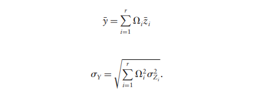

Dựa trên những thông tin trên, chúng ta có thể tiến hành phân tích độ Nhạy của Hàm toán học (1.3). Vậy câu hỏi đặt ra là: Phương pháp phân tích độ nhạy là gì?

Đề cập về phương pháp Phân tích độ nhạy cho các Hàm Toán học, trong Giao trình này Nhóm tác giả đề cập tới nhiều Phương pháp, nhưng với cách tiếp cận đạo hàm (derivative) là được sử dụng phổ biến hơn cả. Cụ thể, giáo trình ghi tại Trang 11:

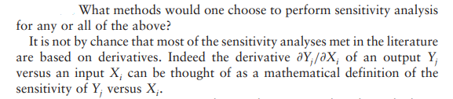

Tuy nhiên, trước tiên chúng ta hãy phân tích độ nhạy của biến đầu ra $Y$ bằng phương pháp đồ thị Scatter plot với các biến đầu vào $Z_{i}$ như hình dưới đây

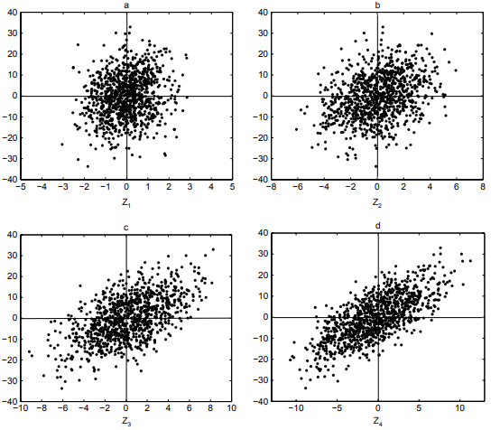

Dựa trên đồ thị trên chúng ta dễ dàng nhận thấy yếu tố đầu ra $Y$ rất nhạy cảm với biến đầu vào $Z_{4}$ và kém nhạy với biến đầu vào $Z_{1}$ bởi vì quan hệ giữa $Y$ và $Z_{4}$ phân bổ rộng hơn so với quan hệ giữa $Y$ và $Z_{1}$ (chỉ quanh quẩn ở tọa độ 0).

Đồng thời, để thực hiện Phân Tích Độ Nhạy cho các hàm toán học như trong Giáo Trình trên, có thể sử dụng Thư viện như SaLib

https://salib.readthedocs.io/en/latest/basics.html#what-is-salib

$\color{blue}{\textbf{1.2 Theo góc độ Kinh Tế Lượng}}$

Các mô hình Kinh tế lượng cũng là một dạng hàm Toán học. Do đó, theo quan điểm cá nhân của chúng tôi, khi phân tích độ nhạy của một mô hình kinh tế lượng bất kỳ, cụ thể trong dự án này là phân tích độ nhạy của Mô Hình Logistic, thì khái niệm Phân tích độ nhạy, phương pháp phân tích độ Nhạy cũng sẽ giống với khái niệm Phân tích Độ Nhạy (Sensitive Analysis), và phương pháp phân tích độ nhạy của các Hàm Toán học, như trong hai Giao trình của các tác giả Châu Âu chúng tôi nêu ra ở trên.

Trước khi đi xâu vào vấn đề, điều quan trọng trước tiên chúng ta phải nhắc lại và hiểu được Mô hình Logistic, để thấy được các nội dung như, đâu là đầu ra, đâu là đầu vào của Mô hình Logistic. Để từ đó, chúng ta sẽ đưa ra các phương pháp, tiếp cận để phân tích độ nhạy của Mô hình Logistic

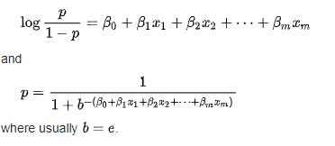

Trên cở sở Mô Hình Logistic nêu ra ở trên, chúng tôi xác định các yếu tố để phân tích Độ Nhạy của Mô Hình như sau:

1. Yếu tố đầu ra: Chỉ số Log Odd, Likelihood, Gía trị dự báo
2. Yếu tố đầu vào: Các hệ số của Mô Hình, Các Biến giải thích, và Phần dư (Lỗi và sai sót)

Trên cơ sở đó, kết hợp với khái niệm về Phân tích độ nhạy, chúng tôi sẽ tiến hành Phân tích Độ Nhạy của Mô Hình Logistic bằng cách thử môt loạt các thay đổi Đầu Vào của Mô hình Logistic như: Các Biến giải thích, và Phần dư (Lỗi và sai sót), để xem các yếu tố Đẩu Ra của Mô hình Logistic như: Chỉ số Log Odd, Likelihood, Gía trị dự báo, sẽ thay đổi như thê nào

Tóm lại, Nhìn chung, Góc độ Kinh tế lượng thì định nghĩa về Phân Tích Độ Nhạy (Sentitive Analysis) không khác xa nhiều đối với định nghĩa về Phân Tích Độ Nhạy của các hàm Toán học trên.Theo đó, chúng ta có thể hiểu Phân Tích Độ Nhạy (Sentitive Analysis) của một Mô Hình Kinh tế Lượng/Thuật Toán nói chung là xem xem sự phản ứng của Mô hình sẽ như thế nào đối với một tình huống bất ổn (uncertainty) được giả định xảy ra. Cụ thể, trong dự án này, chúng ta sẽ tiến hành phân tích Độ Nhạy/Phản ứng của Mô Hình Logistic trong bốn tình huống bất ổn (uncertainty) giả định xảy ra trong các khía cạnh dưới đây:

1. $\textbf{Độ Nhạy của Mô Hình Logistic với từng biến giải thích}$: Khi một biến giải thích trong mô hình biến động, nó sẽ tác động như nào tới Mô Hình.
2. $\textbf{Độ Nhạy của Mô Hình Logistic với số biến giải thích}$: Chúng ta sẽ kiểm tra xem số biến giải thích sẽ tác động như thế nào tới Mô hình. Cụ thể, số biến tăng/giảm sẽ ảnh hưởng như nào tới Mô Hình.
3. $\textbf{Độ Nhạy của Mô Hình Logistic với số quan sát}$: Chúng ta sẽ kiểm tra xem, số quan sát tăng/giảm sẽ ảnh hưởng thế nào tới Mô hình. Chúng ta cần thu thập bao nhiêu quan sát là đủ để ước lượng Mô Hình?
4. $\textbf{Độ Nhạy của Mô Hình Logistic với Độ Nhạy của các Mô hình khác}$: Chúng ta sẽ xem xem với cùng một số biến giải thích và số quan sát như nhau, thì Độ Nhạy của Mô Hình Logistic như thế nào so với các Mô Hình khác.

$$\Large \color{blue}{\textbf{Chi Tiết Quy Trình Thực Nghiệm Dự Án}}$$

$$\Large \color{blue}{\textbf{Phần I: Chuẩn Bị Cấu Hình Programming}}$$

# Lib

```python
import sklearn
print('The scikit-learn version is {}.'.format(sklearn.__version__))
```

```
The scikit-learn version is 0.22.2.post1.
```

```python
import matplotlib
print('matplotlib: {}'.format(matplotlib.__version__))
```

```
matplotlib: 3.0.3
```

```python
from warnings import simplefilter
simplefilter(action='ignore', category=FutureWarning)
```

```python
import os
import itertools
import math

import scipy.interpolate
import scipy.integrate
from timeit import default_timer as timer
import numpy as np
import pandas as pd
from patsy import dmatrices
from scipy import stats
from pandas import set_option
from pandas.plotting import scatter_matrix
from timeit import default_timer as timer
from sklearn.preprocessing import label_binarize
from math import log2
from scipy.stats import sem

import matplotlib.pyplot as plt
import seaborn as sns
import plotly.offline as py
import plotly.express as px
import plotly.graph_objects as go
from plotly.subplots import make_subplots
from sklearn import preprocessing
from sklearn.preprocessing import StandardScaler
from sklearn.preprocessing import LabelEncoder
from sklearn.feature_selection import SelectFromModel
```

```python
#from markdown.extensions.toc import TocExtension
```

```python
import statsmodels.api as sm
from sklearn.linear_model import LogisticRegression
from sklearn.feature_selection import RFE
from sklearn.linear_model import LogisticRegression
from sklearn.discriminant_analysis import LinearDiscriminantAnalysis
from sklearn.linear_model import LinearRegression
from sklearn.svm import LinearSVC
from sklearn.naive_bayes import BernoulliNB, ComplementNB, MultinomialNB
from sklearn.linear_model import Perceptron
from sklearn.linear_model import Lasso
from sklearn.linear_model import LassoLars
from sklearn.linear_model import ElasticNet
from sklearn.linear_model import SGDRegressor
from sklearn.linear_model import SGDClassifier
from sklearn.linear_model import Ridge
from sklearn.linear_model import RidgeClassifier
from sklearn.linear_model import BayesianRidge
from sklearn.linear_model import PassiveAggressiveRegressor
from sklearn.linear_model import PassiveAggressiveClassifier
from sklearn.neighbors import NearestCentroid
from sklearn.neighbors import KNeighborsClassifier
from sklearn.ensemble import RandomForestClassifier
```

```python
#from SALib.sample import saltelli
#from SALib.analyze import sobol
from yellowbrick.regressor import CooksDistance
from yellowbrick.regressor import cooks_distance # quick method
from yellowbrick.regressor import PredictionError
from yellowbrick.classifier import ClassPredictionError
from yellowbrick.model_selection import ValidationCurve
from scipy import stats
from statsmodels.stats.api import anova_lm
from sklearn import metrics
from sklearn import model_selection
from sklearn.model_selection import KFold
from sklearn.model_selection import cross_val_score
from sklearn.model_selection import StratifiedKFold
from sklearn.metrics import classification_report
from sklearn.metrics import confusion_matrix
from sklearn.calibration import CalibratedClassifierCV, calibration_curve

from sklearn.metrics import average_precision_score
from sklearn.metrics import precision_recall_curve
from sklearn.metrics import plot_precision_recall_curve
from sklearn.metrics import f1_score
from sklearn.metrics import (brier_score_loss, precision_score, recall_score)
from sklearn.metrics import accuracy_score
from sklearn.metrics import roc_auc_score
from sklearn.metrics import roc_curve
from yellowbrick.classifier import DiscriminationThreshold
#from sklearn.metrics import plot_confusion_matrix
from sklearn.metrics import auc
from sklearn.metrics import mean_squared_error
from sklearn.model_selection import learning_curve
from sklearn.model_selection import ShuffleSplit
from statsmodels.stats.outliers_influence import variance_inflation_factor
from pyitlib import discrete_random_variable as drv
```

```python
from pickle import dump
from pickle import load
Purple= '\033[95m'
Cyan= '\033[96m'
Darkcyan= '\033[36m'
Blue = '\033[94m'
Green = '\033[92m'
Yellow = '\033[93m'
Red = '\033[91m'
Bold = "\033[1m"
Reset = "\033[0;0m"
Underline= '\033[4m'
End = '\033[0m'
from pprint import pprint
```

# Nhập Dữ Liệu

```python
print(Bold + Blue + 'Thư mục làm việc hiện tại của bạn:' + End)
print(os.getcwd())
```

```
Thư mục làm việc hiện tại của bạn:
C:\Users\Phuong_1\Dropbox\Machine Learning\VCB\VCB Official
```

```python
data= pd.read_csv('default of credit card clients.csv',header=1)
```

$$\Large \color{blue}{\textbf{Phần II: Chuẩn Bị Dữ Liệu}}$$

# Khai phá dữ liệu (EDA)

## Chọn Mẫu

```python
data.head(5)
```

|  | ID | LIMIT_BAL | SEX | EDUCATION | MARRIAGE | AGE | PAY_0 | PAY_2 | PAY_3 | PAY_4 | ... | BILL_AMT4 | BILL_AMT5 | BILL_AMT6 | PAY_AMT1 | PAY_AMT2 | PAY_AMT3 | PAY_AMT4 | PAY_AMT5 | PAY_AMT6 | default payment next month |
| --- | --- | --- | --- | --- | --- | --- | --- | --- | --- | --- | --- | --- | --- | --- | --- | --- | --- | --- | --- | --- | --- |
| 0 | 1 | 20000 | 2 | 2 | 1 | 24 | 2 | 2 | -1 | -1 | ... | 0 | 0 | 0 | 0 | 689 | 0 | 0 | 0 | 0 | 1 |
| 1 | 2 | 120000 | 2 | 2 | 2 | 26 | -1 | 2 | 0 | 0 | ... | 3272 | 3455 | 3261 | 0 | 1000 | 1000 | 1000 | 0 | 2000 | 1 |
| 2 | 3 | 90000 | 2 | 2 | 2 | 34 | 0 | 0 | 0 | 0 | ... | 14331 | 14948 | 15549 | 1518 | 1500 | 1000 | 1000 | 1000 | 5000 | 0 |
| 3 | 4 | 50000 | 2 | 2 | 1 | 37 | 0 | 0 | 0 | 0 | ... | 28314 | 28959 | 29547 | 2000 | 2019 | 1200 | 1100 | 1069 | 1000 | 0 |
| 4 | 5 | 50000 | 1 | 2 | 1 | 57 | -1 | 0 | -1 | 0 | ... | 20940 | 19146 | 19131 | 2000 | 36681 | 10000 | 9000 | 689 | 679 | 0 |

5 rows × 25 columns

## Kiểm tra kích cỡ

```python
print("Số quan sát: %d. Số Biến: %d"%(data.shape))
```

```
Số quan sát: 30000. Số Biến: 25
```

## Kiểm tra Biến

```python
print(Bold+"Tên %d Biến trong Dữ Liệu:"%(len(data.columns))+End)
print(data.columns)
```

```
Tên 25 Biến trong Dữ Liệu:
Index(['ID', 'LIMIT_BAL', 'SEX', 'EDUCATION', 'MARRIAGE', 'AGE', 'PAY_0',
       'PAY_2', 'PAY_3', 'PAY_4', 'PAY_5', 'PAY_6', 'BILL_AMT1', 'BILL_AMT2',
       'BILL_AMT3', 'BILL_AMT4', 'BILL_AMT5', 'BILL_AMT6', 'PAY_AMT1',
       'PAY_AMT2', 'PAY_AMT3', 'PAY_AMT4', 'PAY_AMT5', 'PAY_AMT6',
       'default payment next month'],
      dtype='object')
```

## Kiểm tra Dạng Dữ Liệu

```python
print(Bold+"Dạng Dữ liệu của %d Biến:"%(len(data.columns))+End)
print(data.dtypes)
```

```
Dạng Dữ liệu của 25 Biến:
ID                            int64
LIMIT_BAL                     int64
SEX                           int64
EDUCATION                     int64
MARRIAGE                      int64
AGE                           int64
PAY_0                         int64
PAY_2                         int64
PAY_3                         int64
PAY_4                         int64
PAY_5                         int64
PAY_6                         int64
BILL_AMT1                     int64
BILL_AMT2                     int64
BILL_AMT3                     int64
BILL_AMT4                     int64
BILL_AMT5                     int64
BILL_AMT6                     int64
PAY_AMT1                      int64
PAY_AMT2                      int64
PAY_AMT3                      int64
PAY_AMT4                      int64
PAY_AMT5                      int64
PAY_AMT6                      int64
default payment next month    int64
dtype: object
```

## Kiểm tra Thiếu Biến

```python
print(Bold+"Số giá bị thiếu trong %d Biến"%len(data.columns)+End)
print(data.isnull().sum())
```

```
Số giá bị thiếu trong 25 Biến
ID                            0
LIMIT_BAL                     0
SEX                           0
EDUCATION                     0
MARRIAGE                      0
AGE                           0
PAY_0                         0
PAY_2                         0
PAY_3                         0
PAY_4                         0
PAY_5                         0
PAY_6                         0
BILL_AMT1                     0
BILL_AMT2                     0
BILL_AMT3                     0
BILL_AMT4                     0
BILL_AMT5                     0
BILL_AMT6                     0
PAY_AMT1                      0
PAY_AMT2                      0
PAY_AMT3                      0
PAY_AMT4                      0
PAY_AMT5                      0
PAY_AMT6                      0
default payment next month    0
dtype: int64
```

## Thống Kê Mô Tả

```python
print(Bold+"Thống Kê Mô Tả:"+End)
print(data.describe())
```

```
Thống Kê Mô Tả:
                 ID       LIMIT_BAL           SEX     EDUCATION      MARRIAGE  \
count  30000.000000    30000.000000  30000.000000  30000.000000  30000.000000
mean   15000.500000   167484.322667      1.603733      1.853133      1.551867
std     8660.398374   129747.661567      0.489129      0.790349      0.521970
min        1.000000    10000.000000      1.000000      0.000000      0.000000
25%     7500.750000    50000.000000      1.000000      1.000000      1.000000
50%    15000.500000   140000.000000      2.000000      2.000000      2.000000
75%    22500.250000   240000.000000      2.000000      2.000000      2.000000
max    30000.000000  1000000.000000      2.000000      6.000000      3.000000

                AGE         PAY_0         PAY_2         PAY_3         PAY_4  \
count  30000.000000  30000.000000  30000.000000  30000.000000  30000.000000
mean      35.485500     -0.016700     -0.133767     -0.166200     -0.220667
std        9.217904      1.123802      1.197186      1.196868      1.169139
min       21.000000     -2.000000     -2.000000     -2.000000     -2.000000
25%       28.000000     -1.000000     -1.000000     -1.000000     -1.000000
50%       34.000000      0.000000      0.000000      0.000000      0.000000
75%       41.000000      0.000000      0.000000      0.000000      0.000000
max       79.000000      8.000000      8.000000      8.000000      8.000000

       ...      BILL_AMT4      BILL_AMT5      BILL_AMT6       PAY_AMT1  \
count  ...   30000.000000   30000.000000   30000.000000   30000.000000
mean   ...   43262.948967   40311.400967   38871.760400    5663.580500
std    ...   64332.856134   60797.155770   59554.107537   16563.280354
min    ... -170000.000000  -81334.000000 -339603.000000       0.000000
25%    ...    2326.750000    1763.000000    1256.000000    1000.000000
50%    ...   19052.000000   18104.500000   17071.000000    2100.000000
75%    ...   54506.000000   50190.500000   49198.250000    5006.000000
max    ...  891586.000000  927171.000000  961664.000000  873552.000000

           PAY_AMT2      PAY_AMT3       PAY_AMT4       PAY_AMT5  \
count  3.000000e+04   30000.00000   30000.000000   30000.000000
mean   5.921163e+03    5225.68150    4826.076867    4799.387633
std    2.304087e+04   17606.96147   15666.159744   15278.305679
min    0.000000e+00       0.00000       0.000000       0.000000
25%    8.330000e+02     390.00000     296.000000     252.500000
50%    2.009000e+03    1800.00000    1500.000000    1500.000000
75%    5.000000e+03    4505.00000    4013.250000    4031.500000
max    1.684259e+06  896040.00000  621000.000000  426529.000000

            PAY_AMT6  default payment next month
count   30000.000000                30000.000000
mean     5215.502567                    0.221200
std     17777.465775                    0.415062
min         0.000000                    0.000000
25%       117.750000                    0.000000
50%      1500.000000                    0.000000
75%      4000.000000                    0.000000
max    528666.000000                    1.000000

[8 rows x 25 columns]
```

## Các biến phân loại

```python
print(Bold+"Phân loại của Biến 'SEX':"+End)
print(data["SEX"].unique())
print(Bold+"Phân loại của Biến 'EDUCATION':"+End)
print(data["EDUCATION"].unique())
print(Bold+"Phân loại của Biến 'MARRIAGE':"+End)
print(data["MARRIAGE"].unique())
```

```
Phân loại của Biến 'SEX':
[2 1]
Phân loại của Biến 'EDUCATION':
[2 1 3 5 4 6 0]
Phân loại của Biến 'MARRIAGE':
[1 2 3 0]
```

SEX: Gender (1=male, 2=female)

EDUCATION: (1=graduate school, 2=university, 3=high school, 4=others, 5=unknown, 6=unknown)

MARRIAGE: Marital status (1=married, 2=single, 3=others)

### EDUCATION

```python
print(Bold+"Các phân loại của Biến 'EDUCATION':"+End)
print(data["EDUCATION"].unique())
print(Bold+"Số phân loại của Biến 'EDUCATION':"+End)
print(data["EDUCATION"].value_counts())
```

```
Các phân loại của Biến 'EDUCATION':
[2 1 3 5 4 6 0]
Số phân loại của Biến 'EDUCATION':
2    14030
1    10585
3     4917
5      280
4      123
6       51
0       14
Name: EDUCATION, dtype: int64
```

EDUCATION: (1=graduate school, 2=university, 3=high school, 4=others, 5=unknown, 6=unknown)

```python
data[data["EDUCATION"]==0]=4
data[data["EDUCATION"]==5]=4
data[data["EDUCATION"]==6]=4
```

```python
print(data["EDUCATION"].unique())
print(Bold+"Phân loại của Biến 'MARRIAGE':"+End)
print(data["EDUCATION"].value_counts())
```

```
[2 1 3 4]
Phân loại của Biến 'MARRIAGE':
2    14030
1    10585
3     4917
4      468
Name: EDUCATION, dtype: int64
```

EDUCATION: (1=graduate school, 2=university, 3=high school, 4=others)

### MARRIAGE

```python
print(Bold+"Các phân loại của Biến 'MARRIAGE':"+End)
print(data["MARRIAGE"].unique())
print(Bold+"Số Phân loại của Biến 'MARRIAGE':"+End)
print(data["MARRIAGE"].value_counts())
```

```
Các phân loại của Biến 'MARRIAGE':
[1 2 3 4 0]
Số Phân loại của Biến 'MARRIAGE':
2    15806
1    13477
4      345
3      318
0       54
Name: MARRIAGE, dtype: int64
```

```python
data[data["MARRIAGE"]==0]=4
data[data["MARRIAGE"]==6]=4
```

# Chuẩn bị dữ liệu

## Dữ liệu đầu vào

### Chọn Dữ liệu đầu vào

```python
X=data.iloc[:,1:24]
X.columns
```

```
Index(['LIMIT_BAL', 'SEX', 'EDUCATION', 'MARRIAGE', 'AGE', 'PAY_0', 'PAY_2',
       'PAY_3', 'PAY_4', 'PAY_5', 'PAY_6', 'BILL_AMT1', 'BILL_AMT2',
       'BILL_AMT3', 'BILL_AMT4', 'BILL_AMT5', 'BILL_AMT6', 'PAY_AMT1',
       'PAY_AMT2', 'PAY_AMT3', 'PAY_AMT4', 'PAY_AMT5', 'PAY_AMT6'],
      dtype='object')
```

```python
X.head(5)
```

|  | LIMIT_BAL | SEX | EDUCATION | MARRIAGE | AGE | PAY_0 | PAY_2 | PAY_3 | PAY_4 | PAY_5 | ... | BILL_AMT3 | BILL_AMT4 | BILL_AMT5 | BILL_AMT6 | PAY_AMT1 | PAY_AMT2 | PAY_AMT3 | PAY_AMT4 | PAY_AMT5 | PAY_AMT6 |
| --- | --- | --- | --- | --- | --- | --- | --- | --- | --- | --- | --- | --- | --- | --- | --- | --- | --- | --- | --- | --- | --- |
| 0 | 20000 | 2 | 2 | 1 | 24 | 2 | 2 | -1 | -1 | -2 | ... | 689 | 0 | 0 | 0 | 0 | 689 | 0 | 0 | 0 | 0 |
| 1 | 120000 | 2 | 2 | 2 | 26 | -1 | 2 | 0 | 0 | 0 | ... | 2682 | 3272 | 3455 | 3261 | 0 | 1000 | 1000 | 1000 | 0 | 2000 |
| 2 | 90000 | 2 | 2 | 2 | 34 | 0 | 0 | 0 | 0 | 0 | ... | 13559 | 14331 | 14948 | 15549 | 1518 | 1500 | 1000 | 1000 | 1000 | 5000 |
| 3 | 50000 | 2 | 2 | 1 | 37 | 0 | 0 | 0 | 0 | 0 | ... | 49291 | 28314 | 28959 | 29547 | 2000 | 2019 | 1200 | 1100 | 1069 | 1000 |
| 4 | 50000 | 1 | 2 | 1 | 57 | -1 | 0 | -1 | 0 | 0 | ... | 35835 | 20940 | 19146 | 19131 | 2000 | 36681 | 10000 | 9000 | 689 | 679 |

5 rows × 23 columns

### Đồng bộ hóa đơn vị

```python
standardized_x = preprocessing.scale(X)
standardized_x[1:5]
```

```
array([[-0.3659805 ,  0.81016074,  0.18582826,  0.85855728, -1.02904717,
        -0.87499115,  1.78234817,  0.1388648 ,  0.18874609,  0.23491652,
         1.99231551, -0.65921875, -0.66674657, -0.63925429, -0.62163594,
        -0.60622927, -0.59796638, -0.34194162, -0.21358766, -0.24000461,
        -0.24422965, -0.31413612, -0.18087821],
       [-0.59720239,  0.81016074,  0.18582826,  0.85855728, -0.16115646,
         0.01486052,  0.1117361 ,  0.1388648 ,  0.18874609,  0.23491652,
         0.25313738, -0.29855966, -0.49389911, -0.48240819, -0.44973025,
        -0.41718767, -0.39162956, -0.25029158, -0.19188673, -0.24000461,
        -0.24422965, -0.24868274, -0.01212243],
       [-0.90549825,  0.81016074,  0.18582826, -1.05729503,  0.16430256,
         0.01486052,  0.1117361 ,  0.1388648 ,  0.18874609,  0.23491652,
         0.25313738, -0.05749103, -0.01329269,  0.03284648, -0.23237268,
        -0.18672897, -0.15657889, -0.22119058, -0.16936116, -0.22864528,
        -0.23784635, -0.24416646, -0.23713013],
       [-0.90549825, -1.23432296,  0.18582826, -1.05729503,  2.33402934,
        -0.87499115,  0.1117361 , -0.69666346,  0.18874609,  0.23491652,
         0.25313738, -0.57861809, -0.61131792, -0.16118875, -0.3469972 ,
        -0.34813724, -0.33148158, -0.22119058,  1.33503416,  0.27116536,
         0.26643369, -0.26903874, -0.255187  ]])
```

### Dữ liệu dạng Pandas

```python
standardized_X=pd.DataFrame(data=standardized_x,
                           columns=X.columns)
standardized_X.head()
```

|  | LIMIT_BAL | SEX | EDUCATION | MARRIAGE | AGE | PAY_0 | PAY_2 | PAY_3 | PAY_4 | PAY_5 | ... | BILL_AMT3 | BILL_AMT4 | BILL_AMT5 | BILL_AMT6 | PAY_AMT1 | PAY_AMT2 | PAY_AMT3 | PAY_AMT4 | PAY_AMT5 | PAY_AMT6 |
| --- | --- | --- | --- | --- | --- | --- | --- | --- | --- | --- | --- | --- | --- | --- | --- | --- | --- | --- | --- | --- | --- |
| 0 | -1.136720 | 0.810161 | 0.185828 | -1.057295 | -1.246020 | 1.794564 | 1.782348 | -0.696663 | -0.666599 | -1.530046 | ... | -0.667993 | -0.672497 | -0.663059 | -0.652724 | -0.341942 | -0.227086 | -0.296801 | -0.308063 | -0.314136 | -0.293382 |
| 1 | -0.365981 | 0.810161 | 0.185828 | 0.858557 | -1.029047 | -0.874991 | 1.782348 | 0.138865 | 0.188746 | 0.234917 | ... | -0.639254 | -0.621636 | -0.606229 | -0.597966 | -0.341942 | -0.213588 | -0.240005 | -0.244230 | -0.314136 | -0.180878 |
| 2 | -0.597202 | 0.810161 | 0.185828 | 0.858557 | -0.161156 | 0.014861 | 0.111736 | 0.138865 | 0.188746 | 0.234917 | ... | -0.482408 | -0.449730 | -0.417188 | -0.391630 | -0.250292 | -0.191887 | -0.240005 | -0.244230 | -0.248683 | -0.012122 |
| 3 | -0.905498 | 0.810161 | 0.185828 | -1.057295 | 0.164303 | 0.014861 | 0.111736 | 0.138865 | 0.188746 | 0.234917 | ... | 0.032846 | -0.232373 | -0.186729 | -0.156579 | -0.221191 | -0.169361 | -0.228645 | -0.237846 | -0.244166 | -0.237130 |
| 4 | -0.905498 | -1.234323 | 0.185828 | -1.057295 | 2.334029 | -0.874991 | 0.111736 | -0.696663 | 0.188746 | 0.234917 | ... | -0.161189 | -0.346997 | -0.348137 | -0.331482 | -0.221191 | 1.335034 | 0.271165 | 0.266434 | -0.269039 | -0.255187 |

5 rows × 23 columns

```python
standardized_X.shape
```

```
(30000, 23)
```

## Dữ liệu đầu ra

### Chọn Dữ liệu đầu ra

```python
Y=data["default payment next month"]
Y.head(5)
```

```
0    1
1    1
2    0
3    0
4    0
Name: default payment next month, dtype: int64
```

### Phân bổ Dữ liệu đầu ra

```python
plt.figure(figsize=(8, 5))
ax = sns.countplot(x="default payment next month", data=data)
plt.title("Phân Bổ Giữa Các Trường Hợp Không Xảy Ra Vỡ Nợ và Xảy Ra Vỡ Nợ",fontsize=14,
          fontweight='bold',color='g')
plt.show()
```

[figure not shown]

Có thể thấy sự mất cân đối cực lớn giữa hai giá trị đầu ra. Đây cũng là một trong những vấn đề phổ biến trong các bài toán thực tế. Do đó, sử lý dữ liệu mất cân đối là một trong những bước QUAN TRỌNG đầu tiên, trong đào tạo và ước lượng Mô Hình phân tích.

## Mối quan hệ biến đầu vào và đầu ra

```python
sns.set()
fig=plt.figure(figsize=(12,5))
sns.lmplot(x='LIMIT_BAL',
           y="default payment next month", data=data, logistic=True, y_jitter=.05)
```

[figure not shown]

## Phân tách dữ liệu

Chúng ta sẽ phân tách dữ liệu thành hai phần: Phần Train và phần Validation/Monitoring. Mô hình sẽ được đào tạo trên phần Train, sau đó sẽ kiểm tra hoạt động trên phần Validation/Monitoring. Trong các bài thực tế, phân tách dữ liệu BẮT BUỘC phải thực hiện theo phân tách NGẪU NHIÊN. Tuy nhiên, trong bài toán này chúng ta phân tách dữ liệu bằng tay. Tỷ lệ phân tách sẽ là 70/30.

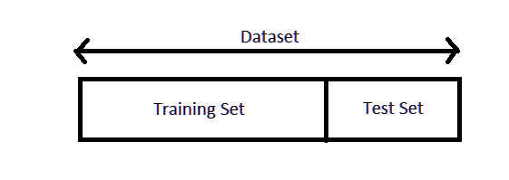

Để có được tỷ lệ phân chia 70/30, thì chúng ta cần xác định được điểm phân chia. Cụ thể, chúng ta sẽ lấy 21000 quan sát đầu tiên trong bộ dữ liệu để đào tạo mô hình, và số còn lại là để kiểm định mô hình như sau

```python
split_cuttoff=round(0.7*len(X),)
print("Điểm phân chia: %d"%split_cuttoff)
```

```
Điểm phân chia: 21000
```

```python
X_train = standardized_X[:split_cuttoff]
X_valid = standardized_X[split_cuttoff:]
```

```python
Y_train = Y[:split_cuttoff]
Y_valid = Y[split_cuttoff:]
```

$$\Large \color{blue}{\textbf{Phần III: Phát Triển Mô Hình}}$$

# Đào tạo Mô Hình

## Xác lập cấu hình và khớp dữ liệu

```python
Logit_Mod1 = sm.Logit(Y_train, X_train)
#result_Logit1 = Logit_Mod1.fit(method='newton')# Phương pháp tìm điểm Log likelood lớn nhất là newton
result_Logit1=Logit_Mod1.fit_regularized()
print(result_Logit1.summary2())
```

```
Optimization terminated successfully.    (Exit mode 0)
            Current function value: 0.6521372104775341
            Iterations: 78
            Function evaluations: 78
            Gradient evaluations: 78
                              Results: Logit
===========================================================================
Model:              Logit                      Pseudo R-squared: -0.214
Dependent Variable: default payment next month AIC:              27435.7628
Date:               2020-03-19 12:35           BIC:              27618.6652
No. Observations:   21000                      Log-Likelihood:   -13695.
Df Model:           22                         LL-Null:          -11284.
Df Residuals:       20977                      LLR p-value:      1.0000
Converged:          1.0000                     Scale:            1.0000
No. Iterations:     78.0000
------------------------------------------------------------------------------
                 Coef.     Std.Err.       z       P>|z|      [0.025     0.975]
------------------------------------------------------------------------------
LIMIT_BAL        0.0022      0.0183     0.1191    0.9052    -0.0336     0.0380
SEX             -0.0295      0.0145    -2.0306    0.0423    -0.0580    -0.0010
EDUCATION       -0.0322      0.0157    -2.0587    0.0395    -0.0629    -0.0015
MARRIAGE        -0.0681      0.0159    -4.2713    0.0000    -0.0994    -0.0369
AGE              0.0368      0.0162     2.2689    0.0233     0.0050     0.0686
PAY_0            0.4645      0.0205    22.6176    0.0000     0.4242     0.5047
PAY_2            0.1076      0.0256     4.1994    0.0000     0.0574     0.1578
PAY_3            0.0601      0.0275     2.1848    0.0289     0.0062     0.1139
PAY_4            0.0147      0.0305     0.4836    0.6287    -0.0450     0.0745
PAY_5            0.0436      0.0311     1.4013    0.1611    -0.0174     0.1045
PAY_6           -0.0031      0.0256    -0.1209    0.9038    -0.0533     0.0471
BILL_AMT1       -0.2402      0.0586    -4.1008    0.0000    -0.3550    -0.1254
BILL_AMT2       -0.0173      0.0793    -0.2178    0.8276    -0.1727     0.1382
BILL_AMT3        0.0290      0.0745     0.3894    0.6970    -0.1170     0.1750
BILL_AMT4        0.2656      0.0735     3.6159    0.0003     0.1216     0.4096
BILL_AMT5       -0.1952      0.0782    -2.4971    0.0125    -0.3485    -0.0420
BILL_AMT6        0.0291      0.0593     0.4903    0.6239    -0.0871     0.1453
PAY_AMT1        -0.0821      0.0220    -3.7369    0.0002    -0.1251    -0.0390
PAY_AMT2        -0.0710      0.0272    -2.6131    0.0090    -0.1242    -0.0177
PAY_AMT3        -0.0095      0.0215    -0.4409    0.6593    -0.0516     0.0326
PAY_AMT4         0.0120      0.0200     0.6014    0.5476    -0.0272     0.0513
PAY_AMT5        -0.0160      0.0197    -0.8120    0.4168    -0.0547     0.0226
PAY_AMT6        -0.0131      0.0165    -0.7899    0.4296    -0.0455     0.0193
===========================================================================
```

## Gía trị fitted đầu ra (log odds)

```python
fitted_LogOdd=result_Logit1.fittedvalues
sns.set()
fig=plt.figure(figsize=(12,5))
plt.plot(fitted_LogOdd,LineWidth=1)
plt.autoscale(enable=True,axis='both',tight=True)
#plt.grid(linestyle=':',which='both',linewidth=2)
#fig.suptitle('Gía trị Log odds ('log(\frac{p}{1-p})')', fontsize=15,fontweight='bold')
plt.title('Gía Trị Log Odds Ước Lượng Từ Mô Hình Logistic',
          fontsize=14,fontweight='bold',color='k')
plt.ylabel(r'$Log(\frac{p}{1-p})$',fontsize=12)
plt.xlabel('%d Giá Trị Log Odd Ước Lượng được từ Mô Hình Logistic'%len(fitted_LogOdd),
           fontsize=12,
           fontweight='normal',color='k')
```

[figure not shown]

$$\Large \color{blue}{\textbf{Phần IV: Đánh Gía và Phân Tích Độ Nhạy Của Mô Hình}}$$

$$\Large \color{blue}{\textbf{In-Sample Sentivitity Analysis and Validation }}$$

Trong phần nội dung này, chúng tôi sẽ tiến hành phân tích Độ nhạy để kiểm định Mô Hình Logistic cho trường hợp $\textbf{In-sample}$. Phần phân tích độ nhạy cho giám sát $\textbf{(monitoring)}$ sẽ được tiến hành ở phần sau $\textbf{Out-Of-Sample}$

# Kiểm Định và Phân tích độ nhạy của Mô Hình

## In-sample Model Validation and Sensitivity Analysis

### Phân Tích nghĩa thóng kê của biến giải thích

```python
pval=result_Logit1.pvalues
print(Red+Bold+'Tổng số biến giải thích trong Mô Hình Logistic: %d'%len(pval)+End)
print(Red+Bold+'Trong đó, Có:'+End)

selecte_valStat=pval[pval.values<0.05]
print(Bold+ Red+"%d Biến giải thích có ý nghĩa thống kê ở mức 0.05. Đó là:"%len(selecte_valStat)+End)
print(round(selecte_valStat,2))

selecte_val=pval[pval.values>0.1]
print(Bold+ Red+"Và %d Biến giải thích không có ý nghĩa thống kê ở mức 0.1. Đó là:"%len(selecte_val)+End)
print(round(selecte_val,2))
```

```
Tổng số biến giải thích trong Mô Hình Logistic: 23
Trong đó, Có:
12 Biến giải thích có ý nghĩa thống kê ở mức 0.05. Đó là:
SEX          0.04
EDUCATION    0.04
MARRIAGE     0.00
AGE          0.02
PAY_0        0.00
PAY_2        0.00
PAY_3        0.03
BILL_AMT1    0.00
BILL_AMT4    0.00
BILL_AMT5    0.01
PAY_AMT1     0.00
PAY_AMT2     0.01
dtype: float64
Và 11 Biến giải thích không có ý nghĩa thống kê ở mức 0.1. Đó là:
LIMIT_BAL    0.91
PAY_4        0.63
PAY_5        0.16
PAY_6        0.90
BILL_AMT2    0.83
BILL_AMT3    0.70
BILL_AMT6    0.62
PAY_AMT3     0.66
PAY_AMT4     0.55
PAY_AMT5     0.42
PAY_AMT6     0.43
dtype: float64
```

### Phân tích Đồ thị Scatter

```python
plt.figure(figsize=(15, 40))
for i,col in enumerate(X_train.columns):
    plt.subplot(6,4,i+1)
    plt.scatter(x=X_train[col],y=fitted_LogOdd)
    plt.xlabel(col)
    plt.ylabel('Fitted Log Odds')
```

[figure not shown]

### Hiệu Ứng Biên (Phương pháp đạo hàm)

Phương pháp này chính là phương pháp Đạo hàm (Derivative). Như đã đề cập ở trên, trong giáo Trình "Global Sensitivity Analysis: The Primer. John Wiley & Sons",mặc dù có những hạn chế riêng, nhưng Nhóm tác giả có nêu ra là phương pháp Đạo hàm được sử dụng phổ biến và khá đơn giản. Cụ thể, trong bài toán này, chúng ta sẽ tính Hiệu ứng biên (Marginal Effects) của Mô Hình Logistic. Cách tính toán chi tiết có thể tham khảo tại các giáo trình về Kinh tế Lượng, đơn cử như "Introductory Econometric: A Modern Approach" của giáo sư Jeffrey M.Wooldridge nổi tiếng trong frequentist econometrics.

```python
param_basedSen=result_Logit1.get_margeff()
print(Bold+"Phân tích độ nhạy của Mô Hình bằng Phương Pháp Đạo Hàm Tính Hiệu Ứng Biên:"+End)
round(param_basedSen.summary_frame(),4)
```

```
Phân tích độ nhạy của Mô Hình bằng Phương Pháp Đạo Hàm Tính Hiệu Ứng Biên:
```

|  | dy/dx | Std. Err. | z | Pr(>\|z\|) | Conf. Int. Low | Cont. Int. Hi. |
| --- | --- | --- | --- | --- | --- | --- |
| LIMIT_BAL | 0.0005 | 0.0042 | 0.1191 | 0.9052 | -0.0078 | 0.0088 |
| SEX | -0.0068 | 0.0033 | -2.0314 | 0.0422 | -0.0134 | -0.0002 |
| EDUCATION | -0.0074 | 0.0036 | -2.0594 | 0.0395 | -0.0145 | -0.0004 |
| MARRIAGE | -0.0157 | 0.0037 | -4.2783 | 0.0000 | -0.0229 | -0.0085 |
| AGE | 0.0085 | 0.0037 | 2.2700 | 0.0232 | 0.0012 | 0.0158 |
| PAY_0 | 0.1071 | 0.0045 | 23.7192 | 0.0000 | 0.0982 | 0.1159 |
| PAY_2 | 0.0248 | 0.0059 | 4.2057 | 0.0000 | 0.0132 | 0.0364 |
| PAY_3 | 0.0138 | 0.0063 | 2.1856 | 0.0288 | 0.0014 | 0.0263 |
| PAY_4 | 0.0034 | 0.0070 | 0.4836 | 0.6287 | -0.0104 | 0.0172 |
| PAY_5 | 0.0100 | 0.0072 | 1.4016 | 0.1610 | -0.0040 | 0.0241 |
| PAY_6 | -0.0007 | 0.0059 | -0.1209 | 0.9038 | -0.0123 | 0.0109 |
| BILL_AMT1 | -0.0554 | 0.0135 | -4.1069 | 0.0000 | -0.0818 | -0.0289 |
| BILL_AMT2 | -0.0040 | 0.0183 | -0.2178 | 0.8276 | -0.0398 | 0.0319 |
| BILL_AMT3 | 0.0067 | 0.0172 | 0.3894 | 0.6969 | -0.0270 | 0.0403 |
| BILL_AMT4 | 0.0612 | 0.0169 | 3.6201 | 0.0003 | 0.0281 | 0.0944 |
| BILL_AMT5 | -0.0450 | 0.0180 | -2.4985 | 0.0125 | -0.0803 | -0.0097 |
| BILL_AMT6 | 0.0067 | 0.0137 | 0.4904 | 0.6239 | -0.0201 | 0.0335 |
| PAY_AMT1 | -0.0189 | 0.0051 | -3.7414 | 0.0002 | -0.0288 | -0.0090 |
| PAY_AMT2 | -0.0164 | 0.0063 | -2.6147 | 0.0089 | -0.0286 | -0.0041 |
| PAY_AMT3 | -0.0022 | 0.0050 | -0.4409 | 0.6593 | -0.0119 | 0.0075 |
| PAY_AMT4 | 0.0028 | 0.0046 | 0.6014 | 0.5476 | -0.0063 | 0.0118 |
| PAY_AMT5 | -0.0037 | 0.0045 | -0.8121 | 0.4167 | -0.0126 | 0.0052 |
| PAY_AMT6 | -0.0030 | 0.0038 | -0.7900 | 0.4295 | -0.0105 | 0.0045 |

### Variance inflation factor

```python
y_vif, X_vif = dmatrices("LIMIT_BAL ~ SEX+EDUCATION+MARRIAGE+AGE+\
PAY_0+PAY_2+PAY_3+PAY_4+PAY_5+PAY_6+BILL_AMT1+BILL_AMT2+\
BILL_AMT3+BILL_AMT4+BILL_AMT5+BILL_AMT6+PAY_AMT1+PAY_AMT2+\
PAY_AMT3+PAY_AMT4+PAY_AMT5", X_train, return_type='dataframe')
vif_df = pd.DataFrame()
vif_df["Gía Trị VIF"] = [variance_inflation_factor(X_vif.values, i) for i in range(X_vif.shape[1])]
vif_df["Biến Giải Thích"] = X_vif.columns
print(Bold+"Kết Qủa Phân Tích Gía Trị VIF:"+End)
print(vif_df)
```

```
Kết Qủa Phân Tích Gía Trị VIF:
    Gía Trị VIF Biến Giải Thích
0      1.005421       Intercept
1      1.023872             SEX
2      1.071348       EDUCATION
3      1.224134        MARRIAGE
4      1.256488             AGE
5      1.867999           PAY_0
6      3.111690           PAY_2
7      3.658301           PAY_3
8      4.423991           PAY_4
9      4.691008           PAY_5
10     3.178488           PAY_6
11    13.890899       BILL_AMT1
12    25.789224       BILL_AMT2
13    21.263001       BILL_AMT3
14    21.134842       BILL_AMT4
15    27.105054       BILL_AMT5
16    15.143860       BILL_AMT6
17     1.577583        PAY_AMT1
18     2.358052        PAY_AMT2
19     1.538178        PAY_AMT3
20     1.636098        PAY_AMT4
21     1.678994        PAY_AMT5
```

### Kiểm Định Wald

Bạn có thể thay đổi Gỉa thuyết theo ý của bạn, bằng cách thay đổi thông số trong phàn "hypotheses" dưới đây. Chẳng hạn, tôi muốn kiểm định Hệ số ước lượng của biến LIMIT_BAL bằng 0, của biến PAY_4 bằng 1, và của Biến PAY_5 bằng 0, xảy ra cùng một lúc

```python
hypotheses='LIMIT_BAL = 0, PAY_4 = 1,PAY_5=0'
wald_test=result_Logit1.wald_test(hypotheses)
print('Kiểm Định giả thuyết:'+hypotheses)
print(wald_test)
#print('Gía grij Thống Kê Chi-2: %.2f. Gía trị xác xuất: %.2f. Degree of Fredoom: %d'%(wald_test))
```

```
Kiểm Định giả thuyết:LIMIT_BAL = 0, PAY_4 = 1,PAY_5=0
<Wald test (chi2): statistic=[[1285.92853941]], p-value=1.6636096079759887e-278, df_denom=3>
```

### Vai Trò Các Biến Giải Thích

```python
model_RFC=RandomForestClassifier()
model_RFC.fit(X_train,Y_train)
name_feature=X_train.columns
RFC_feature_importances=model_RFC.feature_importances_
RFC_selection=pd.DataFrame(data={'Feature':name_feature,
                                      'feature_importance':RFC_feature_importances})

RFC_selection=RFC_selection.set_index(['Feature'])
RFC_selection_temp=100*RFC_selection.sort_values('feature_importance',ascending=False)
RFC_selection_temp['cumulative_importance']=np.cumsum(RFC_selection_temp,axis=0)
RFC_select_cum=RFC_selection_temp#1[ETR_select1['cumulative_importance']<99]

fig=plt.figure(figsize=(12,5))
fig.add_subplot(1,2,1)
plt.barh(RFC_selection['feature_importance'].sort_values(ascending=True).index,
         100*RFC_selection['feature_importance'].sort_values(ascending=True))
plt.autoscale(enable=True, axis='both',tight=True)
plt.ylabel('Biến Giải Thích',fontsize=15)
plt.xlabel('Tỷ Lệ Đóng Góp (%)', fontsize=15)
plt.title('Tỷ Lệ Đóng Góp Từng Biến Giải Thích', size = 16)
plt.grid(which='major',linestyle=':',linewidth=0.9)
for i,v in enumerate(round(100*RFC_selection['feature_importance'].sort_values(ascending=True),2)):
           ax.text(v , i-0.15 , str(v), color='blue')

fig.add_subplot(1,2,2)
axisX=range(1,
      len(RFC_select_cum.sort_values('cumulative_importance',ascending=True).cumulative_importance)+1)
plt.plot(list(axisX),
         RFC_select_cum.sort_values('cumulative_importance',ascending=True).cumulative_importance,
       color='r')
plt.xlabel('Số Biến Giải Thích Trong Mô Hình', size = 14);
plt.ylabel('Tỷ Lệ Đóng Góp Tích Lũy', size = 14)
plt.title('Tỷ Lệ Đóng Góp Tích Lũy Của Các Biến Giải Thích', size = 16)
plt.show()
```

[figure not shown]

### Deviance

```python
LogModel=[]
FittedGLM_LogModel=[]
NumVar=[]
NamVar=[]
Devi=[]
print(Red+"Bạn Đừng Sốt Ruột. Tôi Đang Tính Toán Mà! "+End)
print(Red+".............. "+End)
start = timer()
for i, colnam in enumerate(X_train.columns):
    #print(i)
    Logit_GLMset = sm.GLM(Y_train,X_train[X_train.columns[0:i+1]],
                      family=sm.families.Binomial())
    Fitted_Logit_GLM=Logit_GLMset.fit()
    #
    FittedGLM_LogModel.append(Fitted_Logit_GLM)
     #.append(result_EsLogit.)
    NumVar.append(i+1)
    LogModel.append(i+1)
    NamVar.append(colnam)
    Devi.append(round(Fitted_Logit_GLM.deviance,2))
GLMestimate_results= pd.DataFrame(data={'Mô Hình':LogModel,
                                        'Số Biến':NumVar,
                                        'Biến Thêm Vào':NamVar,
                                        'Kết Qủa Ước Lượng':FittedGLM_LogModel,
                                       'Deviance':Devi},)
print(Red+"Ok! Tôi đã tính toán xong rồi đấy. Hết %.2f Giây bạn nhé "%(timer() - start))
```

```
Bạn Đừng Sốt Ruột. Tôi Đang Tính Toán Mà!
..............
Ok! Tôi đã tính toán xong rồi đấy. Hết 2.62 Giây bạn nhé
```

```python
fig = plt.figure(figsize=(10,5))
plt.plot(GLMestimate_results['Deviance'],GLMestimate_results['Biến Thêm Vào'],
        color='k')
plt.autoscale(enable=True, axis='both',tight=True)
plt.grid(which='major',linestyle=':',linewidth=0.9)
plt.title('Biến Động Gía Trị Deviance Của Mô Hình Logistic',
          fontsize=14,fontweight='bold')
plt.ylabel('Biến Giải Thích Thêm/Bớt', fontsize=11)
plt.xlabel('Gía Trị Deviance', fontsize=11)
plt.show()
```

[figure not shown]

### Phân Tích ANOVA( Analysis Of Variance)

Phân tích ANOVA được thực hiện dễ dàng trong R, khi sử dụng hàm anova.glm()

https://www.rdocumentation.org/packages/stats/versions/3.6.2/topics/anova.glm

Tuy nhiên, trong Python không có hàm này, do đó, trước tiên, chúng tôi tiến hành xây dựng Hàm, Phuong_ANOVA, cho tính toán phân tích của chúng tôi giành cho mục đích phân tích ANOVA như dưới đây.

```python
def Phuong_ANOVA(small_model, big_model):
    """
    Hàm Phuong_ANOVA này dùng để phân tích ANOVA. Khi bạn khai báo hai Mô hình cần so sánh,
    Kết quả trả về sau khi phân tích ANOVA là Gía trị F thống kê và Gía trị xác xuất
    tương ứng của nó
    """
    addtl_params = big_model.df_model - small_model.df_model
    f_stat = (small_model.deviance - big_model.deviance) / (addtl_params * big_model.scale)
    df_numerator = addtl_params
    df_denom = (big_model.fittedvalues.shape[0] - big_model.df_model)
    p_value = stats.f.sf(f_stat, df_numerator, df_denom)
    return (f_stat, p_value)
```

```python
CompetModel=[]
PariModel=[]
NumVar=[]
NamVar=[]
F_val=[]
P_val=[]
print("Bạn Đừng Sốt Ruột. Tôi Đang Phân Tích ANOVA Bằng Hàm Phuong_ANOVA Mà! ")
print("Sẽ Xong Nhanh Thôi Bạn À ")
print(".............. ")
start = timer()
for i, colnam in enumerate(X_train.columns):
    if i+1==23:
        break
    else:
        f_stat, p_val=Phuong_ANOVA(GLMestimate_results.at[i,'Kết Qủa Ước Lượng'],
                            GLMestimate_results.at[i+1,'Kết Qủa Ước Lượng'])
        CompetModel.append(i+1)
        PariModel.append([i+1,i+2])
        NumVar.append(i+1)
        NamVar.append(colnam)
        F_val.append(round(f_stat,2))
        P_val.append(round(p_val,2))
print("Đấy thấy chưa! Tôi đã Phân Tích ANOVA xong rồi đấy. Hết có %.2f Giây Thôi bạn nhé "%(timer() - start))
print("Kết quả phân tích ANOVA Tôi in ra ở dưới đây bạn nhé: ")
ANOVA_results= pd.DataFrame(data={'Mô Hình':CompetModel,
                                   'Số Biến':NumVar,
                                   'Biến Thêm Vào':NamVar,
                                   'Cặp So Sánh':PariModel,
                                    'F-Stats':F_val,
                                    'Prob':P_val},)
pprint(ANOVA_results)
```

```
Bạn Đừng Sốt Ruột. Tôi Đang Phân Tích ANOVA Bằng Hàm Phuong_ANOVA Mà!
Sẽ Xong Nhanh Thôi Bạn À
..............
Đấy thấy chưa! Tôi đã Phân Tích ANOVA xong rồi đấy. Hết có 0.01 Giây Thôi bạn nhé
Kết quả phân tích ANOVA Tôi in ra ở dưới đây bạn nhé:
    Mô Hình  Số Biến Biến Thêm Vào Cặp So Sánh  F-Stats  Prob
0         1        1     LIMIT_BAL      [1, 2]    12.76  0.00
1         2        2           SEX      [2, 3]     0.47  0.49
2         3        3     EDUCATION      [3, 4]    34.60  0.00
3         4        4      MARRIAGE      [4, 5]     1.30  0.25
4         5        5           AGE      [5, 6]  1226.37  0.00
5         6        6         PAY_0      [6, 7]    47.95  0.00
6         7        7         PAY_2      [7, 8]     9.14  0.00
7         8        8         PAY_3      [8, 9]     1.23  0.27
8         9        9         PAY_4     [9, 10]     1.60  0.21
9        10       10         PAY_5    [10, 11]     1.15  0.28
10       11       11         PAY_6    [11, 12]    95.83  0.00
11       12       12     BILL_AMT1    [12, 13]     0.51  0.48
12       13       13     BILL_AMT2    [13, 14]     0.05  0.82
13       14       14     BILL_AMT3    [14, 15]     8.88  0.00
14       15       15     BILL_AMT4    [15, 16]     7.00  0.01
15       16       16     BILL_AMT5    [16, 17]     0.25  0.61
16       17       17     BILL_AMT6    [17, 18]    24.51  0.00
17       18       18      PAY_AMT1    [18, 19]     8.85  0.00
18       19       19      PAY_AMT2    [19, 20]     0.23  0.63
19       20       20      PAY_AMT3    [20, 21]     0.20  0.66
20       21       21      PAY_AMT4    [21, 22]     0.90  0.34
21       22       22      PAY_AMT5    [22, 23]     0.63  0.43
```

### Biến Động Gía Trị Likelihood

Trong phần này, để thấy thêm được vai trò tác động của từng biến giải thích lên kết quả đầu ra của Mô Hình Logistic, chúng tôi tiến hành cố định hệ số của mỗi biến và tiến hành ước lượng các hệ số còn lại trong mô hình dựa trên cùng một bộ dữ liệu. Sau đó, chúng tôi tiến hành Phân tích độ Nhạy của Mô Hình này dựa trên kết quả đầu ra là Likelihood.

```python
Model=[]
Fitted_LogMod=[]
Var_num=[]
var_nam=[]
AIC=[]
BIC=[]
LLNull=[]
Loglike=[]
LR=[]
LR_Pval=[]
pseudo_R2=[]
Deviance_resid=[]
print("Xin vui lòng đợi tôi tý nhé.....")
for i, colnam in enumerate(X_train.columns):
    #print(i)
    Logit_Set = sm.Logit(Y_train,X_train[X_train.columns[0:i+1]])
    result_EsLogit=Logit_Set.fit_regularized()
    #
    Fitted_LogMod.append(result_EsLogit)
    AIC.append(result_EsLogit.aic)
    BIC.append(result_EsLogit.bic)
    #.append(result_EsLogit.)
    LLNull.append(result_EsLogit.llnull)
    Loglike.append(result_EsLogit.llf)
    LR.append(result_EsLogit.llr)
    LR_Pval.append(result_EsLogit.llr_pvalue)
    pseudo_R2.append(result_EsLogit.prsquared)
    Deviance_resid.append(result_EsLogit.resid_dev)
    Var_num.append(i+1)
    Model.append(i+1)
    var_nam.append(colnam)
estimate_results= pd.DataFrame(data={'Mô Hình':Model,
                                     'Kết Qủa Ước Lượng':Fitted_LogMod,
                              'Số Biến':Var_num,
                                     'Tên Biến':var_nam,
                                     'AIC':AIC,
                                     'BIC':BIC,
                                     'Log Likehood không biến':LLNull,
                                     'Log Likehood hàm có biến':Loglike,
                                    'Gía trị LR':LR,
                                     'pseudo-R-squared':pseudo_R2,
                                    # 'Deviance residuals':Deviance_resid
                                    'Gía trị LR_Pval':LR_Pval
                                    },)
```

[output not shown]

[output cut: 61 more lines]

```
Optimization terminated successfully.    (Exit mode 0)
            Current function value: 0.6521737101558525
            Iterations: 84
            Function evaluations: 84
            Gradient evaluations: 84
Optimization terminated successfully.    (Exit mode 0)
            Current function value: 0.6521521772053949
            Iterations: 86
            Function evaluations: 86
            Gradient evaluations: 86
Optimization terminated successfully.    (Exit mode 0)
            Current function value: 0.6521372104775341
            Iterations: 78
            Function evaluations: 78
            Gradient evaluations: 78
```

```python
fig = plt.figure(figsize=(10,5))
#sns.barplot(estimate_results['Log Likehood hàm có biến'],
 #               estimate_results['Tên Biến'],orient='h')
plt.plot(estimate_results['Log Likehood hàm có biến'],
                estimate_results['Tên Biến'])
plt.autoscale(enable=True, axis='both',tight=True)
plt.grid(which='major',linestyle=':',linewidth=0.9)
plt.title('Biến Động Gía Trị Log Likehihood Của Mô Hình Logistic',
          fontsize=14,fontweight='bold')
plt.ylabel('Biến Giải Thích Thêm/Bớt', fontsize=11)
plt.xlabel('Gía Trị Log Likelihood', fontsize=11)
plt.show()
```

[figure not shown]

### Biến Động Tỷ số Thống kê Likelihood chi-squared

Câu hỏi đặt ra trong tình huống phân tích độ nhạy trong tình huống này là, việc thêm các biến giải thích lần lượt vào Mô Hình Logistic có tác động làm tăng Tỷ số Thống Kê Likelihood chi-squared. Lưu ý rằng, một sự tăng của chỉ số này là tín hiệu tốt nói rằng khả năng Mô Hình ước lượng khớp với dữ liệu thực tế gia tăng. Ngược lại, nếu việc thêm một biến mà làm suy giảm chỉ LR Chi-Squared nói lên rằng việc biến thêm đó làm xấu đi khả năng Mô Hình diễn tả trùng sát với dữ liệu thực. Để thực hiện điều này, chúng tôi xuất phát từ việc Mô Hình Logistic chỉ bào gồm một biến, sau đó, lần lượt các biến tiếp theo được thêm vào Mô Hình. Theo đó, chúng tôi tiến hành ước lượng 23 Mô Hình Logistic với Specification khác nhau. Cuối cùng chúng tôi so sánh chỉ số LR Chi-squared của 23 Mô Hình Logistic với nhau để thấy được Độ Nhạy của Mô Hình Logistic với việc thêm/bớt biến giải thích trong Mô Hình.

```python
fig = plt.figure(figsize=(10,5))
plt.plot(estimate_results['Gía trị LR'],estimate_results['Tên Biến'])
plt.autoscale(enable=True, axis='both',tight=True)
plt.grid(which='major',linestyle=':',linewidth=0.9)
plt.title('Khả Năng Khớp Dữ Liệu Thực Của Mô Hình Logistic',
          fontsize=14,fontweight='bold')
plt.ylabel('Tên Biến Giải Thích Được Thêm Vào', fontsize=11)
plt.xlabel('Chỉ số Thống Kê LR Chi-squared', fontsize=11)
plt.show()
```

[figure not shown]

### Biến Động Chỉ Số Pseudo-R-squared

Chỉ số Pseudo-R-squared cũng là một trong những chỉ số cho biết khả năng phản ánh của Mô Hinh Logistic với dữ liệu thực. Do đó, chúng tôi tiến hành phân tích tích độ nhạy của Mô Hình Logistic qua sự biến động của chỉ số Pseudo-R-Squared với việc thêm/bơt lần lượt từng biến giải thích.

```python
fig = plt.figure(figsize=(10,5))
plt.plot(estimate_results['pseudo-R-squared'],estimate_results['Tên Biến'])
plt.autoscale(enable=True, axis='both',tight=True)
plt.grid(which='major',linestyle=':',linewidth=0.9)
plt.title('Khả Năng Khớp Dữ Liệu Thực Của Mô Hình Logistic',
          fontsize=14,fontweight='bold')
plt.ylabel('Tên Biến Giải Thích Được Thêm/Bớt', fontsize=11)
plt.xlabel('Chỉ số Pseudo-R-squared', fontsize=11)
plt.show()
```

[figure not shown]

### Sự phức tạp của Mô Hình

$$AIC=2*k- 2*Log(\hat{L})$$$$BIC=Log(N)*k- 2*Log(\hat{L})$$

```python
fig = plt.figure(figsize=(10,5))
plt.plot(estimate_results['AIC'],estimate_results['Tên Biến'],
        Linestyle='-.',label='AIC')
plt.plot(estimate_results['BIC'],estimate_results['Tên Biến'],
        Linestyle='-',label='BIC')
plt.autoscale(enable=True, axis='both',tight=True)
plt.grid(which='major',linestyle=':',linewidth=0.9)
plt.title('Sự Phức Tạp Của Mô Hình',
          fontsize=14,fontweight='bold')
plt.ylabel('Tên Biến Giải Thích Được Thêm/Bớt', fontsize=11)
plt.xlabel('Chỉ số AIC/BIC', fontsize=11)
plt.legend()
plt.show()
```

[figure not shown]

### Độ Nhạy Của Mô Hình Với Số Biến Giải Thích

Trong trường hợp này, để phân tích độ Nhạy của Mô Hình Logistic, chúng tôi chọn yếu tố đầu ra của Mô Hình là là kết quả dự báo, và yếu tố đầu vào thay đổi là Số Biến giải thích. Cụ thể chúng tôi sẽ kiểm chứng xem, khi chúng tôi thay đổi số biến đầu vào của Mô Hình Logistic thì khả năng dự báo của nó sẽ là như thế nào. Chỉ tiêu Accuracy sẽ được chọn để lượng hóa Độ Nhạy của Mô Hình Logistic trong tình huống này

```python
estimator =LogisticRegression(solver='liblinear',penalty='l1',fit_intercept=False)
competing_model_score_df = []
score_model = []
numvars = []
training_time=[]
#training_time.append(timer() - start)
print(Red+"Please wait! I am done soon..."+End)
for num in range(len(X_train.columns)):
    start = timer()
    selector_fit=RFE(estimator, num+1, step=1).fit(X_train,Y_train)
    selector_score=selector_fit.score(X_train,Y_train)
    score_model.append(selector_score)
    numvars.append(num+1)
    training_time.append(timer() - start)
compared_results= pd.DataFrame(data={'Số biến trong mô hình':numvars,
                              'Độ nhạy của Mô Hình (Score)':score_model,
                                    'Thời gian (s)':training_time})
print(Bold+'Độ Nhạy Của Mô Hình Logistic Theo Số Biến Giải Thích'+End)
compared_results.sort_values(by=['Độ nhạy của Mô Hình (Score)'],ascending=False)
```

```
Please wait! I am done soon...
Độ Nhạy Của Mô Hình Logistic Theo Số Biến Giải Thích
```

|  | Số biến trong mô hình | Độ nhạy của Mô Hình (Score) | Thời gian (s) |
| --- | --- | --- | --- |
| 16 | 17 | 0.598190 | 2.728182 |
| 17 | 18 | 0.597667 | 2.369348 |
| 19 | 20 | 0.597619 | 1.724869 |
| 18 | 19 | 0.597619 | 2.033256 |
| 14 | 15 | 0.597571 | 2.946483 |
| 13 | 14 | 0.597571 | 3.172427 |
| 15 | 16 | 0.597524 | 2.799610 |
| 20 | 21 | 0.597429 | 1.420333 |
| 22 | 23 | 0.597238 | 0.450727 |
| 21 | 22 | 0.597238 | 0.999919 |
| 12 | 13 | 0.594524 | 3.470256 |
| 7 | 8 | 0.591000 | 3.882048 |
| 11 | 12 | 0.590048 | 3.624660 |
| 10 | 11 | 0.589571 | 3.579513 |
| 8 | 9 | 0.587714 | 3.964471 |
| 9 | 10 | 0.586619 | 3.919385 |
| 4 | 5 | 0.580000 | 4.501744 |
| 3 | 4 | 0.579476 | 4.638993 |
| 5 | 6 | 0.574048 | 4.303363 |
| 2 | 3 | 0.573619 | 4.150520 |
| 6 | 7 | 0.572048 | 4.219308 |
| 1 | 2 | 0.423429 | 4.314390 |
| 0 | 1 | 0.411476 | 4.404936 |

```python
sns.set()
fig=plt.figure(figsize=(12,5))
plt.plot(compared_results['Độ nhạy của Mô Hình (Score)'],LineWidth=2)
#plt.autoscale(enable=True,axis='both',tight=True)
plt.title('Độ Nhạy Của Mô Hình Logistic Theo Số Biến Giải Thích',
          fontsize=14,fontweight='bold',color='k')
plt.ylabel('Chỉ Số Accuracy',fontsize=12)
plt.xlabel('Số Biến Giải Thích Trong Mô Hình Logistic',
           fontsize=12,
           fontweight='normal',color='k')
```

[figure not shown]

### Độ Nhạy Của Mô Hình Với Số Quan Sát

Phần này trả lời cho câu hỏi: Số quan sát sẽ ảnh hưởng như thế nào tới Mô Hình Logistic. Cụ thể, liệu rằng càng nhiều quan sát thì khả năng hoạt động của Mô Hình càng hiệu quả?

Để thực hiện điều này, chúng ta tiến hành ước lượng mô hình trên các tập dữ liệu có độ lớn khác nhau. Ví dụ, độ lớn của dữ liệu dùng để ước lượng Mô hình Logistic sẽ dần theo tỷ lệ chỉ chiếm từ 10%, 33%,... cho tới toàn bộ 100%. Thêm vào đó, trong mỗi khoảng Dữ liệu đó, chúng ta lại ước lượng Mô hình 100 lần, với tỷ lệ phân chia là 80/20. Cuối cùng, giá trị trung bình phần diện tích nằm dưới đường the Receiver Operating Characteristic Curve (ROC-AUC), sẽ dùng làm thước đo hiệu quả của Mô hình theo thay đổi của kích cỡ dữ liệu đào tạo.

Kết quả, chúng ta thấy rằng Số Biến quan sát có ảnh hưởng tới hiệu quả hoạt động của Mô Hình Logistic. Cụ thể, nếu chỉ dùng 2000 Quan sát, chúng ta sẽ thấy có hiện tượng Mô Hình Logistic bị nhiều lỗi trong dự báo, và lỗi này giảm đi khi số quan sát tăng lên. Tuy nhiên, số quan sát trên 14000 thì chúng ta không cần thiết phải thu thập thêm dữ liệu nữa. Thay vì đó, để năng cao hoạt động của Mô Hình Logistic thì chúng ta sẽ nghiên cứu ở khía cạnh khác như số biến giải thích hoặc sử dụng các Mô hình khác

```python
cv = ShuffleSplit(n_splits=100, test_size=0.2, random_state=0)
#cv = KFold(n_splits=10, random_state=7)
estimator=LogisticRegression(solver='liblinear',penalty='l1',fit_intercept=False)
X=X_train
y=Y_train
train_sizes=[0.1, 0.33, 0.55, 0.78, 1. ]
print(Red+Bold+"Xin Vui Lòng Đợi, Tôi Đang Tính Toán Mà! "+End)
print(Red+".............. "+End)
start = timer()
train_sizes, train_scores, test_scores = learning_curve(estimator,
                                                            X, y, train_sizes=train_sizes,
                                                            cv=cv, scoring='roc_auc',
                                                            n_jobs=4)
train_scores_mean = np.mean(train_scores, axis=1)
train_scores_std = np.std(train_scores, axis=1)
test_scores_mean = np.mean(test_scores, axis=1)
test_scores_std = np.std(test_scores, axis=1)
print(Red+Bold+"Ok! Tôi đã tính toán xong rồi đấy. Hết %.2f Giây bạn nhé "%(timer() - start))
```

```
Xin Vui Lòng Đợi, Tôi Đang Tính Toán Mà!
..............
Ok! Tôi đã tính toán xong rồi đấy. Hết 92.11 Giây bạn nhé
```

```python
plt.figure(figsize=(12, 5))
plt.title("Tác Động Của Số Quan Sát Tới Độ Nhạy Học Của Mô Hình",
         fontsize=14,fontweight='bold',color='b')
plt.plot(train_sizes, train_scores_mean, marker='o', color="blue",
             label="Đường Cong Học (Learning Curve) tính trên dữ liệu đào tạo", linestyle='--')
plt.plot(train_sizes, test_scores_mean, marker='v', color="green",
             label="Đường Cong Học (Learning Curve) tính trên dữ liệu kiểm tra")
plt.autoscale(enable=True, axis='both',tight=True)
plt.grid(which='major',linestyle=':',linewidth=0.9)
plt.ylabel('Phần diện tích dưới đường ROC-AUC',fontsize=12)
plt.xlabel('Số Quan Sát Sử Dụng',
           fontsize=12,
           fontweight='normal',color='k')
plt.legend(loc="best")
```

[figure not shown]

### Deviance Residual

Trong phần phân tích độ nhạy này, chúng tôi kiểm tra yếu tố đầu ra là Deviance Residual của Mô Hình Logistic nếu giả định yếu tố đầu vào là Phần dư thay đổi từ Phân Phổi Thường Chuẩn và Phân Phối Logistic Chuẩn.

```python
fig=plt.figure(figsize=(12,5))
fig.add_subplot(1,2,1)
sns.distplot(GLMestimate_results.at[22,'Kết Qủa Ước Lượng'].resid_deviance,
             bins=150, hist=True,kde=True)#, fit=stats.gamma);
plt.title('Histogram \n of Deviance Residual',fontweight='bold')
plt.xlabel('Deviance Residual')
plt.ylabel('Densities')
plt.autoscale(enable=True, axis='both',tight=True)
fig.add_subplot(1,2,2)
stats.probplot(GLMestimate_results.at[22,'Kết Qủa Ước Lượng'].resid_deviance,
               dist="norm", plot=plt)
plt.autoscale(enable=True, axis='both',tight=True)
plt.title("Normal Q-Q plot \n of Deviance Residual",fontweight='bold')
plt.show()
```

[figure not shown]

### Working Residuals

Working residuals are quantities that are used by the IRLS algorithm during the fitting process. Careful analysis of the working residuals is an additional tool that can be used to assess the quality of model fit.

```python
GLMestimate_results.at[i,'Kết Qủa Ước Lượng'].resid_working.head()
```

```
0    1.355052
1    2.208469
2   -1.998360
3   -2.113431
4   -1.823015
dtype: float64
```

### Log Loss

This is the loss function used in (multinomial) logistic regression and extensions of it such as neural networks, defined as the negative log-likelihood of the true labels given a probabilistic classifier’s predictions. The log loss is only defined for two or more labels. For a single sample with true label yt in {0,1} and estimated probability yp that yt = 1, the log loss is

$$-log P(yt|yp) = -(yt log(yp) + (1 - yt) log(1 - yp))$$

```python
var_nam=[]
Log_loss=[]
kfold = model_selection.KFold(n_splits=20, random_state=7)
estimator_logit=LogisticRegression(solver='liblinear',penalty='l1',fit_intercept=False)
print(Red+Bold+"Xin Vui Lòng Đợi, Tôi Đang Tính Toán Mà! "+End)
print(Red+".............. "+End)
start = timer()
for i, colnam in enumerate(X_train.columns):
    cv_LogLossResults = model_selection.cross_val_score(estimator_logit, X_train[X_train.columns[0:i+1]],
                                                        Y_train,cv=kfold, scoring='neg_log_loss')
    var_nam.append(colnam)
    Log_loss.append(cv_LogLossResults)
print(Red+Bold+"Ok! Tôi đã tính toán xong rồi đấy. Hết %.2f Giây bạn nhé. Bạn xem Đồ Thị Đi này "%(timer() - start))

fig = plt.figure(figsize=(10,5))
ax = fig.add_subplot(111)
plt.boxplot(Log_loss,vert=False, showmeans=True)
#ax.set_yticklabels(names)
plt.grid(which='major',linestyle=':',linewidth=0.9)
plt.title('Biến Động Gía Trị Log Loss Của Mô Hình Logistic Với Số Biến Giải Thích',
          fontsize=14,fontweight='bold')
plt.ylabel('Số Biến Giải Thích', fontsize=11)
plt.xlabel('Phân phối Gía Trị Log Loss', fontsize=11)
plt.show()
```

```
Xin Vui Lòng Đợi, Tôi Đang Tính Toán Mà!
..............
Ok! Tôi đã tính toán xong rồi đấy. Hết 45.39 Giây bạn nhé. Bạn xem Đồ Thị Đi này
```

[figure not shown]

### Cook’s Distance

Cook’s Distance is a measure of an observation or instances’ influence on a linear regression. Instances with a large influence may be outliers and datasets that have a large number of highly influential points might not be good predictors to fit linear models.

```python
CookDisVisual= CooksDistance()
print(Red+Bold+"Bạn Cứ Bình Tĩnh. Tôi Đang Tính Cook's Distance Cho Bạn Mà! Đừng Tắt Máy Tính nhé! "+End)
print(Red+".............. "+End)
start = timer()
CookDisVisual.fit(X_train, Y_train)
print(Bold+Blue+"Đây! Tôi đã tính toán xong và vẽ đồ thị về Cook's Distance ở dưới cho Bạn rồi đấy. Hết %.2f Phút bạn nhé.  "%((timer() - start)/60)+End)
CookDisVisual.show()
```

```
Bạn Cứ Bình Tĩnh. Tôi Đang Tính Cook's Distance Cho Bạn Mà! Đừng Tắt Máy Tính nhé!
..............
Đây! Tôi đã tính toán xong và vẽ đồ thị về Cook's Distance ở dưới cho Bạn rồi đấy. Hết 3.40 Phút bạn nhé.
```

[figure not shown]

### Thống Kê Kolmogorov–Smirnov (KS)

Thống Kê KS được sử dụng phổ biến trong industry

https://www.accenture.com/gb-en/~/media/accenture/conversion%20assets/dotcom/documents/global/pdf/dualpub_7/accenture-credit-risk-model-monitoring.pdf

https://www.listendata.com/2019/07/KS-Statistics-Python.html

```python
logreg=LogisticRegression(solver='liblinear',penalty='l1',fit_intercept=False)
logreg_fitted=logreg.fit(X_train, Y_train)
get_prob_train=pd.DataFrame(logreg_fitted.predict_proba(X_train))

ks_train=pd.DataFrame({'prob':get_prob_train[1],
                      'target':Y_train},)

ks_train['target0'] = 1 - ks_train['target']
ks_train['bucket'] = pd.qcut(ks_train['prob'], 10)
grouped = ks_train.groupby('bucket', as_index = False)
kstable_train = pd.DataFrame()
kstable_train['min_prob'] = grouped.min()['prob']
kstable_train['max_prob'] = grouped.max()['prob']
kstable_train['events']   = grouped.sum()['target']
kstable_train['nonevents'] = grouped.sum()['target0']
kstable_train = kstable_train.sort_values(by="min_prob", ascending=False).reset_index(drop = True)
kstable_train['event_rate'] = (kstable_train.events / ks_train['target'].sum()).apply('{0:.2%}'.format)
kstable_train['nonevent_rate'] = (kstable_train.nonevents / ks_train['target0'].sum()).apply('{0:.2%}'.format)
kstable_train['cum_eventrate']=(kstable_train.events / ks_train['target'].sum()).cumsum()
kstable_train['cum_noneventrate']=(kstable_train.nonevents / ks_train['target0'].sum()).cumsum()
kstable_train['KS'] = np.round(kstable_train['cum_eventrate']-kstable_train['cum_noneventrate'], 3) * 100
kstable_train

kstable_train['cum_eventrate']= kstable_train['cum_eventrate'].apply('{0:.2%}'.format)
kstable_train['cum_noneventrate']= kstable_train['cum_noneventrate'].apply('{0:.2%}'.format)
kstable_train.index = range(1,11)
kstable_train.index.rename('Decile', inplace=True)
pd.set_option('display.max_columns', 9)

print(Blue+Bold + "Gía Trị Thống Kê Kolmogorov–Smirnov (In-sample) Là %.2f "%max(kstable_train['KS']) +"%"+\
      " Tại điểm Thứ %d Của Dữ Liệu"%\
      (kstable_train.index[kstable_train['KS']==max(kstable_train['KS'])][0]))
kstable_train
```

```
Gía Trị Thống Kê Kolmogorov–Smirnov (In-sample) Là 36.20 % Tại điểm Thứ 2 Của Dữ Liệu
```

| Decile | min_prob | max_prob | events | nonevents | event_rate | nonevent_rate | cum_eventrate | cum_noneventrate | KS |
| --- | --- | --- | --- | --- | --- | --- | --- | --- | --- |
| 1 | 0.710067 | 0.991134 | 1433 | 667 | 29.88% | 4.12% | 29.88% | 4.12% | 25.8 |
| 2 | 0.585745 | 0.709948 | 867 | 1233 | 18.08% | 7.61% | 47.96% | 11.73% | 36.2 |
| 3 | 0.542766 | 0.585507 | 468 | 1632 | 9.76% | 10.07% | 57.71% | 21.80% | 35.9 |
| 4 | 0.519374 | 0.542761 | 350 | 1750 | 7.30% | 10.80% | 65.01% | 32.60% | 32.4 |
| 5 | 0.499740 | 0.519374 | 290 | 1810 | 6.05% | 11.17% | 71.06% | 43.77% | 27.3 |
| 6 | 0.475361 | 0.499735 | 252 | 1848 | 5.25% | 11.40% | 76.31% | 55.17% | 21.1 |
| 7 | 0.433831 | 0.475330 | 266 | 1834 | 5.55% | 11.32% | 81.86% | 66.49% | 15.4 |
| 8 | 0.392613 | 0.433828 | 326 | 1774 | 6.80% | 10.95% | 88.66% | 77.44% | 11.2 |
| 9 | 0.334970 | 0.392559 | 295 | 1805 | 6.15% | 11.14% | 94.81% | 88.58% | 6.2 |
| 10 | 0.004421 | 0.334932 | 249 | 1851 | 5.19% | 11.42% | 100.00% | 100.00% | 0.0 |

### Ma Trận Confusion

Chúng tôi quan sát thấy rằng, Ma Trận Confusion là cách tiếp cận phổ biến trong Industry cũng như trong phát triển các Chương Trình Máy Học/AI. Vì vậy, trong nội dung này chúng tôi cũng sẽ phân tích độ nhạy của Mô Hình Logistic dựa trên hướng tiếp cận này

```python
Y_Fitted = logreg_fitted.predict(X_train)
print(Blue+'Khả Năng Dự Báo Của Mô Hình Logistic (In-sample Forecast): {:.2f}'.\
      format(logreg.score(X_train, Y_train))+End)
confus_matrix = confusion_matrix(Y_train, Y_Fitted)
```

```
Khả Năng Dự Báo Của Mô Hình Logistic (In-sample Forecast): 0.60
```

```python
group_names = ['Dự Báo Đúng Không Xảy Ra Vỡ Nợ \n (True Negative)',
               'Dự Báo Sai Có Xảy Ra Vỡ Nợ \n (False Positive)\n Type I Error',
               'Dự Báo Sai Không Xảy Vỡ Nợ \n (False Negative)\n Type II Error',
               'Dự Báo Đúng Có Xảy Ra Vỡ Nợ \n (True Positive)']
group_counts = ["{0:0.0f}".format(value) for value in
                confus_matrix.flatten()]
group_percentages = ["{0:.2%}".format(value) for value in
                     confus_matrix.flatten()/np.sum(confus_matrix)]
labels = [f"{v1}\n{v2}\n{v3}" for v1, v2, v3 in
          zip(group_names,group_counts,group_percentages)]
labels = np.asarray(labels).reshape(2,2)
accuracy  = np.trace(confus_matrix) / float(np.sum(confus_matrix))
precision = confus_matrix[1,1] / sum(confus_matrix[:,1])
recall    = confus_matrix[1,1] / sum(confus_matrix[1,:])
f1_score  = 2*precision*recall / (precision + recall)
stats_text = "\n\nAccuracy={:0.3f}\nPrecision={:0.3f}\nRecall={:0.3f}\nF1 Score={:0.3f}".format(
                accuracy,precision,recall,f1_score)
plt.figure(figsize=(12, 7))
plt.title("Ma Trận Confusion \n (In-sample Forecast)",fontsize=14,
          fontweight='bold',color='tab:orange')
sns.heatmap(confus_matrix,center=True, annot=labels, fmt='', cmap='Oranges')
plt.ylabel('Gía Trị Thực Tế',fontsize=12,
          fontweight='bold',color='tab:orange')
plt.xlabel('Gía Trị Dự Báo Của Mô Hình Logistic \n (In-sample Forecast)',fontsize=12,
          fontweight='bold',color='tab:orange')
#plt.xlabel(stats_text)
plt.show()
```

[figure not shown]

### Chỉ Tiêu AUROC

```python
FPR=[]
TPR=[]
roc_auc_train=[]
FPR_valid=[]
TPR_valid=[]
roc_auc_valid=[]
Model_nume=[]
var_name=[]
print(Red+"Xin vui lòng đợi tôi tý nhé....."+End)
for i, colnam in enumerate(X_train.columns):
    mylogreg=LogisticRegression(solver='liblinear',penalty='l1',fit_intercept=False)
    mylogreg.fit(X_train[X_train.columns[0:i+1]], Y_train)
    logit_roc_auc = roc_auc_score(Y_train, mylogreg.predict(X_train[X_train.columns[0:i+1]]))
    fpr, tpr, thresholds = roc_curve(Y_train,
                                     mylogreg.predict_proba(X_train[X_train.columns[0:i+1]])[:,1])
    roc_auc_train.append(auc(fpr,tpr))
    Model_nume.append(i+1)
    var_name.append(colnam)
    FPR.append(fpr)
    TPR.append(tpr)

    fpr_valid, tpr_valid, thresholds_valid = roc_curve(Y_valid,
                                     mylogreg.predict_proba(X_valid[X_valid.columns[0:i+1]])[:,1])



    logit_roc_auc_valid = roc_auc_score(Y_valid,
                                        mylogreg.predict(X_valid[X_valid.columns[0:i+1]]))
    fpr_valid, tpr_valid, thresholds_valid = roc_curve(Y_valid,
                                                       mylogreg.predict_proba(X_valid[X_valid.columns[0:i+1]])[:,1])#)


    roc_auc_valid.append(auc(fpr_valid,tpr_valid))
    FPR_valid.append(fpr_valid)
    TPR_valid.append(tpr_valid)

print(Red+"Cảm ơn bạn đã chờ. Tôi làm xong rồi ấy. In kết quả ra đi"+End)
roc_results= pd.DataFrame(data={'Mô Hình':Model_nume,
                                     'Tên Biến':var_name,
                                    'Gía trị TPR':TPR,
                                     'Gía trị FPR':FPR,
                               'Diện tích':roc_auc_train,
                               'Gía trị TPR_valid':TPR_valid,
                               'Gía trị FPR_valid':FPR_valid,
                               'Diện tích valid':roc_auc_valid,},)
```

```
Xin vui lòng đợi tôi tý nhé.....
Cảm ơn bạn đã chờ. Tôi làm xong rồi ấy. In kết quả ra đi
```

```python
plt.figure(figsize=(12, 5))
plt.plot(roc_results.at[0,'Gía trị FPR'],
         roc_results.at[0,'Gía trị TPR'],
         label='Mô Hình Logistic %d biến (Diện tích =%.2f)'%(roc_results.at[0,'Mô Hình'],
                                                        roc_results.at[0,'Diện tích']),
        linestyle=':')
plt.plot(roc_results.at[4,'Gía trị FPR'],
         roc_results.at[4,'Gía trị TPR'],
         label='Mô Hình Logistic %d biến (Diện tích =%.2f)'%(roc_results.at[4,'Mô Hình'],
                                                        roc_results.at[4,'Diện tích']),
        linestyle='-.')


plt.plot(roc_results.at[22,'Gía trị FPR'],
         roc_results.at[22,'Gía trị TPR'],
         label='Mô Hình Logistic %d biến (Diện tích =%.2f)'%(roc_results.at[22,'Mô Hình'],
                                                        roc_results.at[22,'Diện tích']),
        linestyle='--')
plt.plot([0, 1], [0, 1], color='navy', linestyle='-')
plt.autoscale(enable=True, axis='both',tight=True)
plt.suptitle('Biến động AUC-ROC Của Mô Hình Logistic Theo Số Biến Giải Thích',
          fontsize=15,fontweight='bold',color='b')
plt.title('(In-Sample Sensitivity Analysis)',
          fontsize=15,fontweight='bold',color='b')
plt.ylabel('Chỉ Số Sensitivity', fontsize=12,color='b',fontweight='bold')
plt.xlabel('Chỉ Số Specificity',fontsize=12,color='b',fontweight='bold')
plt.legend(loc="lower right")

plt.show()
```

[figure not shown]

### Bootstrap Analysis AUROC

```python
n_bootstraps = 1000
rng_seed = 42  # control reproducibility
bootstrapped_scores_train = []
rng = np.random.RandomState(rng_seed)
for i in range(n_bootstraps):
    # bootstrap by sampling with replacement on the prediction indices
    indices = rng.randint(0, len(Y_Fitted), len(Y_Fitted))
    if len(np.unique(Y_train[indices])) < 2:
        # We need at least one positive and one negative sample for ROC AUC
        # to be defined: reject the sample
        continue

    score_roauc_train = roc_auc_score(Y_train[indices], Y_Fitted[indices])
    bootstrapped_scores_train.append(score_roauc_train)
    #print("Bootstrap #{} ROC area: {:0.3f}".format(i + 1, score))

plt.figure(figsize=(13, 5))
sns.distplot(bootstrapped_scores_train, bins=50, kde=True,hist=True)
plt.suptitle('Histogram of %d Boostrap for ROAUC scores \n (In-sample)'%len(bootstrapped_scores_train),
         fontsize=15,fontweight='bold',color='b')
plt.ylabel('Tần Xuất', fontweight='bold',
           color='b',fontsize=12)
plt.xlabel('Chỉ Số ROAUC',fontweight='bold',fontsize=12,color='b')
plt.show()
```

[figure not shown]

### Khoảng Tin Cậy Cho AUROC

```python
Num_bootstrap=[]
lopbootstrapped_scores_train=[]
noboot=[10,20,50,100,500,800,1000]
for i,n_boostrap in enumerate(noboot):
    #print(i,n_boostrap)
    Num_bootstrap.append(n_boostrap)
    lopbootstrapped_scores_train.append([])
    rng_seed = 42  # control reproducibility
    loprng_train = np.random.RandomState(rng_seed)
    for i_bot in range(n_boostrap):
        #print(i_bot)
        indices_trainlop = loprng_train.randint(0, len(Y_Fitted), len(Y_Fitted))
        if len(np.unique(Y_train[indices_train])) < 2:
            continue
        lopscore_roauc_train = roc_auc_score(Y_train[indices_trainlop ], Y_Fitted[indices_trainlop ])
        lopbootstrapped_scores_train[i].append(lopscore_roauc_train)
#lopbootstrapped_scores_train

confidence_lower_lop_train=[]
confidence_upper_lop_train=[]
for i in range(len(lopbootstrapped_scores_train)):
    #rint(i)
    sorted_scores_lop_train = np.array(lopbootstrapped_scores_train[i])
    sorted_scores_lop_train.sort()
    confidence_lower_lop_train.append(round(sorted_scores_lop_train[int(0.05 * len(sorted_scores_lop_train))],4))
    confidence_upper_lop_train.append(round(sorted_scores_lop_train[int(0.95 * len(sorted_scores_lop_train))],4))


print(Bold+'Khoảng Tin Cậy 95(%) Của AUROC Qua Các Lần Bootstrap Khác Nhau (In-Sample)'+End)
print(pd.DataFrame({'Số Bootstrap':Num_bootstrap,
             'Lower Bound':confidence_lower_lop_train,
             'Upper Bound':confidence_upper_lop_train}))
```

[output not shown]

### Hệ Số Gini (Accuracy Ratio AR)

```python
Gini_train=[]
for i in range(0,len(roc_results)):
    Gini_train.append(2*roc_results.at[i,'Diện tích']-1)
plt.figure(figsize=(12, 5))
plt.suptitle('Biến động Hệ Số Gini Của Mô Hình Logistic Theo Số Biến Giải Thích \n In-Sample',
          fontsize=15,fontweight='bold',color='b')
plt.plot(Gini_train, color='navy', linestyle='-', label='Hệ Số Gini')
plt.xlabel('Số Biến Giải Thích Trong Mô Hình', fontweight='bold',
           color='b',fontsize=12)
plt.ylabel('Hệ Số Gini',fontweight='bold',fontsize=12,color='b')
plt.legend(loc="lower right")
plt.autoscale(enable=True,axis='x',tight=True)
plt.show()
```

[figure not shown]

### Bootstrap for Gini (Accuracy Ratio AR)

```python
bootstrapped_GINI_train=[(2*p-1) for p in bootstrapped_scores_train]
plt.figure(figsize=(13, 5))
sns.distplot(bootstrapped_GINI_train, bins=50, kde=True,hist=True)
plt.suptitle('Histogram of %d Boostrap for GINI (Accuracy Ratio AP) \n (In-sample)'%len(bootstrapped_scores_train),
         fontsize=15,fontweight='bold',color='b')
plt.ylabel('Tần Xuất', fontweight='bold',
           color='b',fontsize=12)
plt.xlabel('Chỉ Số GINI (Accuracy Ratio AP) ',fontweight='bold',fontsize=12,color='b')
plt.show()
```

[figure not shown]

### CAP – Cumulative Accuracy Profile

```python
total_train = len(Y_train)
 # Đếm Số Vỡ Nợ Trong Dữ Liệu
one_count_train = np.sum(Y_train)
# Đếm Số Không Vỡ Nợ Trong Dữ Liệu
zero_count_train = total_train - one_count

lm_train = [y for _, y in sorted(zip(Y_Fitted, Y_train), reverse = True)]
x_axis_train = np.arange(0, total_train + 1)
y_axis_train = np.append([0], np.cumsum(lm_train))


plt.figure(figsize = (10, 6))
plt.plot([0, total_train], [0, one_count_train], c = 'b',
         linestyle = '-', label = 'Mô Hình Ngẫu Nhiên')
plt.plot(x_axis_train, y_axis_train, c = 'b', label = 'Mô Hình Logistic',
         linestyle = ':',linewidth = 6)
plt.plot([0, one_count_train, total_train],
         [0, one_count_train, one_count_train], linestyle = '-.',
         c = 'grey', linewidth = 2, label = 'Mô Hình Hoàn Hảo')
plt.suptitle('Phân Tích CAP Của Mô Hình Logistic \n In-Sample Forecast',
          fontsize=15,fontweight='bold',color='b')
plt.xlabel('Số Người Nợ Ngân Hàng', fontweight='bold',
            color='b',fontsize=12)
plt.ylabel('Số Người Bị Vỡ Nợ Ngân Hàng',fontweight='bold',fontsize=12,color='b')
plt.legend(loc="lower right")
plt.autoscale(enable=True,axis='x',tight=True)
plt.show()
```

[figure not shown]

### In-Sample Discriminatory Power Của Mô Hình Logistic

```python
target_names = ['Không Xảy Ra Vỡ Nợ', 'Xảy Ra Vỡ Nợ']
print(Bold+'Báo Cáo Khả Năng Phân Loại giữa Xảy Ra Và Không Xảy Ra Vỡ Nợ Của Mô Hình Logistic \n In-Sample'+End)
print(classification_report(Y_train, Y_Fitted, target_names=target_names))
```

```
Báo Cáo Khả Năng Phân Loại giữa Xảy Ra Và Không Xảy Ra Vỡ Nợ Của Mô Hình Logistic
 In-Sample
                    precision    recall  f1-score   support

Không Xảy Ra Vỡ Nợ       0.87      0.56      0.68     16204
      Xảy Ra Vỡ Nợ       0.33      0.71      0.45      4796

          accuracy                           0.60     21000
         macro avg       0.60      0.64      0.56     21000
      weighted avg       0.74      0.60      0.63     21000
```

### Plotting In-Sample Discriminatory Power Của Mô Hình Logistic

```python
visualizer = DiscriminationThreshold(LogisticRegression(solver='liblinear',
                                                        penalty='l1',fit_intercept=False))

visualizer.fit(X_train, Y_train)
visualizer.show()
```

[figure not shown]

### Lorenz Curve

https://www.kaggle.com/batzner/gini-coefficient-an-intuitive-explanation

```python
Lor_data = zip(Y_train, Y_Fitted)
sorted_Lor_data = sorted(Lor_data, key=lambda d: d[1])
sorted_Lor_actual = [d[0] for d in sorted_Lor_data]


lorenz = np.cumsum(sorted_Lor_actual) / np.sum(sorted_Lor_actual)
lorenz = np.insert(lorenz, 0, 0)
lorenz[0], lorenz[-1]

plt.figure(figsize = (10, 6))
plt.plot(np.arange(lorenz.size)/(lorenz.size-1), lorenz, linestyle = '-.',
            linewidth = 2,color='darkgreen',label='Lorenz Curve ')
plt.plot(np.arange(lorenz.size)/(lorenz.size-1),
         np.arange(lorenz.size)/(lorenz.size-1),
         linewidth = 1,color='r',label='Line of Equality')
plt.fill_between(np.arange(lorenz.size)/(lorenz.size-1),
                 np.arange(lorenz.size)/(lorenz.size-1), lorenz,
                 color='C1', alpha=0.7,
                 label='Gini Index')

plt.legend(loc="lower right")
plt.autoscale(enable=True,axis='x',tight=True)
plt.suptitle('Đường Cong Lorenz\n In-Sample Validation',
          fontsize=15,fontweight='bold',color='b')
plt.ylabel('Tỷ Lệ Gía Trị Thực Lũy Tiến \n Cumulative Share of Actual Values',
           fontweight='bold',fontsize=12,color='b')
plt.xlabel('Tỷ Lệ Dự Báo Lũy Tiến \n Cumulative Share of Predictions', fontweight='bold',
            color='b',fontsize=12)
plt.show()
```

[figure not shown]

### Điểm Brier và Calibration Plots

The position of the points or the curve relative to the diagonal can help to interpret the probabilities; for example:

- Below the diagonal: The model has over-forecast; the probabilities are too large.
- Above the diagonal: The model has under-forecast; the probabilities are too small.

https://machinelearningmastery.com/how-to-calculate-nonparametric-rank-correlation-in-python/

```python
Y_pred_train = logreg_fitted.predict(X_train)
Default_Pred_prob_train = logreg_fitted.predict_proba(X_train)[:, 1]
NonDef_Pred_prob_train = logreg_fitted.predict_proba(X_train)[:, 0]

Default_brier_score_train=brier_score_loss(Y_train, Default_Pred_prob_train,
                                           pos_label=Y_train.max())
NonDef_brier_score_train=brier_score_loss(Y_train, NonDef_Pred_prob_train ,
                                           pos_label=Y_train.max())

fraction_of_default_train, Default_mean_predicted_value_train = \
            calibration_curve(Y_train, Default_Pred_prob_train, n_bins=50)
fraction_of_nondefault_train, NonDef_mean_predicted_value_train = \
            calibration_curve(Y_train, NonDef_Pred_prob_train, n_bins=50)

fig=plt.figure(figsize=(12,5))
plt.suptitle('Calibration plots  (reliability curve)')
fig.add_subplot(1,2,1)
plt.plot(Default_mean_predicted_value_train, fraction_of_default_train, "s-",
                 label="The Brier Score of Logistic Model for Default (%1.3f)" % (Default_brier_score_train))
plt.plot([0, 1], [0, 1], "k:", label="Perfectly calibrated")
plt.autoscale(enable=True,axis='x',tight=True)
plt.ylabel("Tỷ Lệ Vỡ Nợ")

plt.xlabel("Gía Trị Xác Xuất Dự Báo Trung Bình Cho Trường Hợp Vỡ Nợ")
plt.legend(loc="upper left")

fig.add_subplot(1,2,2)
plt.plot(NonDef_mean_predicted_value_train, fraction_of_nondefault_train, "s-",
                 label="The Brier Score of Logistic Model for NonDefault (%1.3f)" % (NonDef_brier_score_train))
plt.plot([0, 1], [1, 0], "k:", label="Perfectly calibrated")
plt.autoscale(enable=True,axis='x',tight=True)
plt.ylabel("Tỷ Lệ Không Vỡ Nợ")

plt.xlabel("Gía Trị Dự Báo Trung Bình")
plt.legend(loc="upper left")


#fig.add_subplot(1,2,2)
#plt.hist(Default_Pred_prob_train, range=(0, 1), bins=10, label=name,
#                histtype="step", lw=2)
#plt.ylabel("Tần Xuất")
#plt.xlabel("Gía Trị Dự Báo Trung Bình")
plt.show()
```

[figure not shown]

### The Information Entropy

Theo định nghĩa của Uỷ Ban Basel (Basel II), The Information Entropy $H(p)$ của một sự kiên có xác xuất xảy ra là $p$ được tính như sau

$$H(p) = -\Big[p*log(p) +(1-p)*log(1-p)\Big]$$

$$H(p) = -\Big[p*log(p)\Big]$$

Đây là cách tiếp cận phổ biến khi chúng tôi nghiên cứu các tài liệu khác ngoài Khuyến nghị của Basel II.

The intuition behind quantifying information is the idea of measuring how much surprise there is in an event. Those events that are rare (low probability) are more surprising and therefore have more information those events that are common (high probability).

- Low Probability Event: High Information (surprising).
- High Probability Event: Low Information (unsurprising).

```python
info_entro_defTrain = [-(p*log2(p)+(1-p)*log2(1-p)) for p in Default_Pred_prob_train]
fig=plt.figure(figsize=(12,5))
plt.scatter(Default_Pred_prob_train, info_entro_defTrain, marker='.')
plt.title('Xác Xuất Dự Báo Từ Mô Hình Logistic Và \
Chỉ Số Information Entropy Xảy Ra Vỡ Nợ\n (In-Sample)',
         fontsize=15,fontweight='bold',color='b')
plt.xlabel('Xác Xuất Dự Báo Từ Mô Hình Logistic',
          fontsize=12,fontweight='bold',color='b')
plt.ylabel('Chỉ Số Information Entropy',
          fontsize=12,fontweight='bold',color='b')
plt.show()
```

[figure not shown]

### Kullback-Leibler Distance

Theo định nghĩa Basel II:

$$Kullback-Leibler Distance = H(p) − HS$$

```python
conEn_train=drv.entropy_conditional(Y_Fitted.tolist(),Y_train.tolist())
```

```
array(0.96100764)
```

### Precision-Recall Curve

```python
average_precision_train = average_precision_score(Y_train, Y_Fitted)
disp = plot_precision_recall_curve(logreg_fitted, X_train, Y_train)
disp.ax_.set_title('2-class Precision-Recall curve\n In-sample Validation \nAP={0:0.2f}'.format(average_precision_valid))
plt.show()
```

[figure not shown]

### In-Sample Prediction Error

```python
classes = ['Không Có Rủi Ro Vỡ Nợ', 'Rủi Ro Vỡ Nợ']
Logit_PredErVisual= ClassPredictionError(LogisticRegression(solver='liblinear',
                                                        penalty='l1',fit_intercept=False),
                                        classes=classes)
Logit_PredErVisual.fit(X_train, Y_train)
Logit_PredErVisual.score(X_train, Y_train)
plt.figure(figsize = (10, 6))
Logit_PredErVisual.show()
```

[figure not shown]

### Đường Cong Kiểm Định (Validation Curve)

```python
cv = StratifiedKFold(12)
param_range = np.linspace(0.1,2,10)
viz = ValidationCurve(
    LogisticRegression(solver='liblinear',penalty='l1',fit_intercept=False),
    param_name='C', param_range=param_range,
    logx=True, cv=cv, scoring="accuracy", n_jobs=8,
)
viz.fit(X_train,Y_train)
viz.show()
```

[figure not shown]

### Xác Xuất Vỡ Nợ (PD) Và Tỷ Lệ Duyệt Khoản Vay

```python
threshold_accepted_train = np.quantile(Default_Pred_prob_train, 0.85)
fig=plt.figure(figsize=(12,5))
plt.suptitle('Gía Trị Xác Xuất (PD) Ứớc Lượng Từ Mô Hình Logistic và Ngưỡng Duyệt Khoản Vay \
\n (In-Sample Forecast)')
sns.distplot(Default_Pred_prob_train,hist=True,rug=False,
             kde_kws={'linestyle':'--'},label='PD Ước Lượng')
plt.axvline(threshold_accepted_train,lw='3',color='r')#,
            #label='Gía Trị Ngưỡng Một Khoản Vay Được Duyệt')
plt.annotate('\n Gía Trị Ngưỡng (%.2f) \n Một Khoản Vay \n Được Duyệt'%threshold_accepted_train,
             xy=(0.66, 4.2), xytext=(0.7, 4),
           arrowprops=dict(facecolor='r', shrink=0.01))

plt.ylabel("Tần Xuất")

plt.xlabel("The In-Sample Probability of Default (PD)")
plt.legend(loc="lower left")
plt.show()
```

[figure not shown]

$$\Large \color{blue}{\textbf{Phần V: Giam Sát Hoạt Động Của Mô Hình}}$$

$$\Large \color{blue}{\textbf{Model Monitoring}}$$

$$\Large \color{blue}{\textbf{Out-Of-Sample Sentivitity Analysis and Validation}}$$

## Out-of-sample (Model Monitoring)

Phần này chúng ta sẽ tiến hành Giam sát hoạt động của Mô Hình, cụ thể chúng ta sẽ theo hướng tiếp cận của Industry như của Ủy Ban Basel, Ngân Hàng Trung ương Đức (Bundesbank), Của Công Ty Xếp Hạng Tín Nhiệm Moody hay Finity của Úc, etc..Đặc biệt, chúng tôi tập trung theo những khuyến nghị của Uỷ Ban Basel.Do đó, các chỉ tiêu sau được chúng tôi sử dụng như

1. Hệ Số Gini.
2. Chỉ số AUC-ROC
3. Chỉ tiêu K-P.
4. Ma Trận Confustion.
5. Khả năng Phân Loại (Classification Report)
6. Lỗi loại I, Lỗi loại II.

Tham khảo kỹ hơn về giám sát Mô Hình tại các trang sau

https://www.bis.org/publ/bcbs_wp14.pdf

https://www.bis.org/ifc/events/ws_micro_macro/nehrebecka_paper.pdf

https://www.bundesbank.de/resource/blob/704150/b9fa10a16dfff3c98842581253f6d141/mL/2003-10-01-dkp-01-data.pdf

https://www.crowe.com/insights/credit-risk-model-validation

https://www.moodysanalytics.com/-/media/products/Model-Monitoring.pdf

https://www.finity.com.au/wp-content/uploads/2014/05/07.-Model-monitoring.pdf

https://www.accenture.com/gb-en/~/media/accenture/conversion%20assets/dotcom/documents/global/pdf/dualpub_7/accenture-credit-risk-model-monitoring.pdf

### Out-Of-Sample Predictor Error

```python
classes = ['Không Có Rủi Ro Vỡ Nợ', 'Rủi Ro Vỡ Nợ']
Logit_PredErVisual= ClassPredictionError(LogisticRegression(solver='liblinear',
                                                        penalty='l1',fit_intercept=False),
                                        classes=classes)
Logit_PredErVisual.fit(X_train, Y_train)
Logit_PredErVisual.score(X_valid, Y_valid)
plt.figure(figsize = (10, 6))
Logit_PredErVisual.show()
```

[figure not shown]

### Out-Of-Sample Confusion Matrix

```python
Y_Forecast= logreg_fitted.predict(X_valid)
print(Blue+'Khả Năng Dự Báo Của Mô Hình Logistic (Out-Of-sample Forecast): {:.2f}'.\
      format(logreg.score(X_valid, Y_valid))+End)
confus_matrix_valid = confusion_matrix(Y_valid, Y_Forecast)
```

```
Khả Năng Dự Báo Của Mô Hình Logistic (Out-Of-sample Forecast): 0.61
```

```python
group_names = ['Dự Báo Đúng Không Xảy Ra Vỡ Nợ \n (True Negative)',
               'Dự Báo Sai Có Xảy Ra Vỡ Nợ \n (False Positive)\n Type I Error',
               'Dự Báo Sai Không Xảy Vỡ Nợ \n (False Negative)\n Type II Error',
               'Dự Báo Đúng Có Xảy Ra Vỡ Nợ \n (True Positive)']
group_counts = ["{0:0.0f}".format(value) for value in
                confus_matrix.flatten()]
group_percentages = ["{0:.2%}".format(value) for value in
                     confus_matrix.flatten()/np.sum(confus_matrix)]
labels = [f"{v1}\n{v2}\n{v3}" for v1, v2, v3 in
          zip(group_names,group_counts,group_percentages)]
labels = np.asarray(labels).reshape(2,2)
accuracy_valid  = np.trace(confus_matrix_valid) / float(np.sum(confus_matrix_valid))
precision_valid = confus_matrix_valid[1,1] / sum(confus_matrix_valid[:,1])
recall_valid    = confus_matrix_valid[1,1] / sum(confus_matrix_valid[1,:])
f1_score_valid  = 2*precision_valid*recall_valid / (precision_valid + recall_valid)
stats_text = "\n\nAccuracy={:0.3f}\nPrecision={:0.3f}\nRecall={:0.3f}\nF1 Score={:0.3f}".format(
                accuracy_valid,precision_valid,recall_valid,f1_score_valid)
plt.figure(figsize=(15, 7))
plt.title("Ma Trận Confusion \n (Out-Of-sample Forecast)",fontsize=14,
          fontweight='bold',color='tab:orange')
sns.heatmap(confus_matrix_valid,center=True, annot=labels, fmt='', cmap='Oranges')
plt.ylabel('Gía Trị Thực Tế',fontsize=12,
          fontweight='bold',color='tab:orange')
plt.xlabel('Gía Trị Dự Báo Của Mô Hình Logistic \n (Out-Of-sample Forecast)',fontsize=12,
          fontweight='bold',color='tab:orange')
#plt.xlabel(stats_text)
plt.show()
```

[figure not shown]

### Out-Of-Sample AU-ROC

```python
plt.figure(figsize=(12, 5))
plt.plot(roc_results.at[0,'Gía trị FPR_valid'],
         roc_results.at[0,'Gía trị TPR_valid'],
         label='Mô Hình Logistic %d biến (AUC-ROC =%.2f)'%(roc_results.at[0,'Mô Hình'],
                                                        roc_results.at[0,'Diện tích valid']),
        linestyle=':')
plt.plot(roc_results.at[4,'Gía trị FPR_valid'],
         roc_results.at[4,'Gía trị TPR_valid'],
         label='Mô Hình Logistic %d biến (AUC-ROC =%.2f)'%(roc_results.at[4,'Mô Hình'],
                                                        roc_results.at[4,'Diện tích valid']),
        linestyle='-.')


plt.plot(roc_results.at[22,'Gía trị FPR_valid'],
         roc_results.at[22,'Gía trị TPR_valid'],
         label='Mô Hình Logistic %d biến (AUC-ROC =%.2f)'%(roc_results.at[22,'Mô Hình'],
                                                        roc_results.at[22,'Diện tích valid']),
        linestyle='--')

plt.suptitle('Biến động Chỉ Số AUC-ROC Của Mô Hình Logistic Theo Số Biến Giải Thích',
          fontsize=15,fontweight='bold')
plt.title('Out-Of-Sample',
          fontsize=15,fontweight='bold')
plt.plot([0, 1], [0, 1], color='navy', linestyle='-')
plt.xlabel('Chỉ Số Specificity', fontweight='bold',fontsize=12)
plt.ylabel('Chỉ Số Sensitivity',fontweight='bold',fontsize=12)
plt.legend(loc="lower right")
plt.show()
```

[figure not shown]

### Bootstrap AU-ROC

```python
y_valid=Y_valid
y_valid=np.asarray(y_valid)

n_bootstraps = 1000
rng_seed = 12  # control reproducibility
bootstrapped_scores_valid = []
rng_valid = np.random.RandomState(rng_seed)
for i in range(n_bootstraps):
    indices_valid = rng_valid.randint(0, len(Y_Forecast), len(Y_Forecast))
    #print(indices_valid)

    if len(np.unique(y_valid[indices_valid])) < 2:
        continue
    score_roauc_valid = roc_auc_score(y_valid[indices_valid], Y_Forecast[indices_valid])
    bootstrapped_scores_valid.append(score_roauc_valid)

plt.figure(figsize=(13, 5))
sns.distplot(bootstrapped_scores_valid, bins=50, kde=True,hist=True)
plt.suptitle('Distribution of %d Boostrap for ROAUC scores \n (Out-Of-Sample)'%len(bootstrapped_scores_valid),
         fontsize=15,fontweight='bold',color='b')
plt.ylabel('Tần Xuất', fontweight='bold',
           color='b',fontsize=12)
plt.xlabel('Chỉ Số ROAUC',fontweight='bold',fontsize=12,color='b')
plt.show()
```

[figure not shown]

### Khoảng Tin Cậy Cho AUROC

```python
Num_bootstrap_valid=[]
lopbootstrapped_scores_valid=[]
noboot=[10,20,50,100,500,800,1000]
for i,n_boostrap in enumerate(noboot):
    #print(i,n_boostrap)
    Num_bootstrap_valid.append(n_boostrap)
    lopbootstrapped_scores_valid.append([])
    rng_seed = 42  # control reproducibility
    loprng_valid = np.random.RandomState(rng_seed)
    for i_bot in range(n_boostrap):
        #print(i_bot)
        indices_validlop = loprng_valid.randint(0, len(Y_Forecast), len(Y_Forecast))
        if len(np.unique(y_valid[indices_validlop])) < 2:
            continue
        lopscore_roauc_valid = roc_auc_score(y_valid[indices_validlop], Y_Forecast[indices_validlop])
        lopbootstrapped_scores_train[i].append(lopscore_roauc_train)
#lopbootstrapped_scores_train

confidence_lower_lop_valid=[]
confidence_upper_lop_valid=[]
for i in range(len(lopbootstrapped_scores_valid)):
    #rint(i)
    sorted_scores_lop_valid = np.array(lopbootstrapped_scores_train[i])
    sorted_scores_lop_valid.sort()
    confidence_lower_lop_valid.append(round(sorted_scores_lop_valid[int(0.05 * len(sorted_scores_lop_valid))],4))
    confidence_upper_lop_valid.append(round(sorted_scores_lop_valid[int(0.95 * len(sorted_scores_lop_valid))],4))


print(Bold+'Khoảng Tin Cậy 95(%) Của AUROC Qua Các Lần Bootstrap Khác Nhau (Out-Of-Sample)'+End)
print(pd.DataFrame({'Số Bootstrap':Num_bootstrap_valid,
             'Lower Bound':confidence_lower_lop_valid,
             'Upper Bound':confidence_upper_lop_valid}))
```

[output not shown]

### Hệ Số Gini (Accuracy Ratio AR)

Hệ Số Gini là một trong Hai Hệ Số được sử dụng phổ biến nhất trong Industry. Trong Lĩnh Vực Ngân hàng, Ủy Ban Basel cũng khuyến nghị sử dụng hệ số Gini này và cả hệ số AUC-ROC. $$Gini=2*AUC - 1$$

```python
Gini_valid=[]
for i in range(0,len(roc_results)):
    Gini_valid.append(2*roc_results.at[i,'Diện tích valid']-1)
plt.figure(figsize=(12, 5))
plt.suptitle('Biến động Hệ Số Gini Của Mô Hình Logistic Theo Số Biến Giải Thích \n Out-Of-Sample',
          fontsize=15,fontweight='bold',color='b')
plt.plot(Gini_valid, color='navy', linestyle='-', label='Hệ Số Gini')
plt.xlabel('Số Biến Giải Thích Trong Mô Hình', fontweight='bold',
           color='b',fontsize=12)
plt.ylabel('Hệ Số Gini',fontweight='bold',fontsize=12,color='b')
plt.legend(loc="lower right")
plt.autoscale(enable=True,axis='x',tight=True)
plt.show()

#plt.figure(figsize=(12, 5))
#sns.distplot(Gini_valid,bins=3, kde=True)
#plt.title('Phân Phối Của Hệ Số Gini')
#plt.autoscale(enable=True, axis='both',tight=True)
#plt.xlabel('Hệ Số Gini', fontsize=12)
#plt.ylabel('Tần Xuất ',fontsize=12)
#plt.show()
```

[figure not shown]

### Bootstrap for Gini (Accuracy Ratio AR)

```python
bootstrapped_GINI_valid=[(2*p-1) for p in bootstrapped_scores_valid]
plt.figure(figsize=(13, 5))
sns.distplot(bootstrapped_GINI_valid, bins=50, kde=True,hist=True)
plt.suptitle('Distribution of %d Boostrap for GINI (Accuracy Ratio AP) \n (Out-Of-Sample)'%len(bootstrapped_scores_valid),
         fontsize=15,fontweight='bold',color='b')
plt.ylabel('Tần Xuất', fontweight='bold',
           color='b',fontsize=12)
plt.xlabel('Chỉ Số GINI (Accuracy Ratio AP) ',fontweight='bold',fontsize=12,color='b')
plt.show()
```

[figure not shown]

### CAP – Cumulative Accuracy Profile

```python
total = len(Y_valid)
 # Đếm Số Vỡ Nợ Trong Dữ Liệu Kiểm Định
one_count = np.sum(Y_valid)
# Đếm Số Không Vỡ Nợ Trong Dữ Liệu Kiểm Định
zero_count = total - one_count

lm = [y for _, y in sorted(zip(Y_Forecast, Y_valid), reverse = True)]
x_axis_valid = np.arange(0, total + 1)
y_axis_valid = np.append([0], np.cumsum(lm))


plt.figure(figsize = (10, 6))
plt.plot([0, total], [0, one_count], c = 'b',
         linestyle = '-', label = 'Mô Hình Ngẫu Nhiên')
plt.plot(x_axis_valid, y_axis_valid, c = 'b', label = 'Mô Hình Logistic',
         linestyle = ':',linewidth = 5)
plt.plot([0, one_count, total], [0, one_count, one_count], linestyle = '-.',
         c = 'grey', linewidth = 2, label = 'Mô Hình Hoàn Hảo')
plt.suptitle('Phân Tích CAP Của Mô Hình Logistic \n Out-Of-Sample Forecast',
          fontsize=15,fontweight='bold',color='b')
plt.xlabel('Số Người Nợ Ngân Hàng', fontweight='bold',
            color='b',fontsize=12)
plt.ylabel('Số Người Bị Vỡ Nợ Ngân Hàng',fontweight='bold',fontsize=12,color='b')
plt.legend(loc="lower right")
plt.autoscale(enable=True,axis='x',tight=True)
plt.show()
```

[figure not shown]

### Discriminatory Power Của Mô Hình Logistic

```python
target_names = ['Không Xảy Ra Vỡ Nợ', 'Xảy Ra Vỡ Nợ']
print(Bold+'Báo Cáo Khả Năng Phân Loại giữa Xảy Ra Và Không Xảy Ra Vỡ Nợ Của Mô Hình Logistic \n Out-of-Sample'+End)
print(classification_report(Y_valid, Y_Forecast, target_names=target_names))
```

```
Báo Cáo Khả Năng Phân Loại giữa Xảy Ra Và Không Xảy Ra Vỡ Nợ Của Mô Hình Logistic
 Out-of-Sample
                    precision    recall  f1-score   support

Không Xảy Ra Vỡ Nợ       0.88      0.58      0.70      7160
      Xảy Ra Vỡ Nợ       0.30      0.69      0.42      1840

          accuracy                           0.61      9000
         macro avg       0.59      0.64      0.56      9000
      weighted avg       0.76      0.61      0.64      9000
```

### Lorenz Curve Monitoring

```python
Lor_data_valid = zip(Y_valid, Y_Forecast)
sorted_Lor_data_valid = sorted(Lor_data_valid, key=lambda d: d[1])
sorted_Lor_actual_valid = [d[0] for d in sorted_Lor_data_valid]


lorenz_valid = np.cumsum(sorted_Lor_actual_valid) / np.sum(sorted_Lor_actual_valid)
lorenz_valid = np.insert(lorenz_valid, 0, 0)
lorenz_valid[0], lorenz_valid[-1]

plt.figure(figsize = (10, 6))
plt.plot(np.arange(lorenz_valid.size)/(lorenz_valid.size-1), lorenz_valid, linestyle = '-.',
            linewidth = 2,color='darkgreen',label='Lorenz Curve ')
plt.plot(np.arange(lorenz.size)/(lorenz.size-1),
         np.arange(lorenz.size)/(lorenz.size-1),
         linewidth = 1,color='r',label='Line of Equality')
plt.fill_between(np.arange(lorenz.size)/(lorenz.size-1),
                 np.arange(lorenz.size)/(lorenz.size-1), lorenz,
                 color='C1', alpha=0.7,
                 label='Gini Index')

plt.legend(loc="lower right")
plt.autoscale(enable=True,axis='x',tight=True)
plt.suptitle('Đường Cong Lorenz\n Out-Of-Sample Validation',
          fontsize=15,fontweight='bold',color='b')
plt.ylabel('Tỷ Lệ Gía Trị Thực Lũy Tiến \n Cumulative Share of Actual Values',
           fontweight='bold',fontsize=12,color='b')
plt.xlabel('Tỷ Lệ Dự Báo Lũy Tiến \n Cumulative Share of Predictions', fontweight='bold',
            color='b',fontsize=12)
plt.show()
```

[figure not shown]

### Điểm Brier and Calibration Curves

```python
Y_pred_valid = logreg_fitted.predict(X_valid)
Default_Pred_prob_valid = logreg_fitted.predict_proba(X_valid)[:, 1]
NonDef_Pred_prob_valid = logreg_fitted.predict_proba(X_valid)[:, 0]

Default_brier_score_valid=brier_score_loss(Y_valid, Default_Pred_prob_valid,
                                           pos_label=Y_valid.max())
NonDef_brier_score_valid=brier_score_loss(Y_valid, NonDef_Pred_prob_valid ,
                                           pos_label=Y_valid.max())

fraction_of_default_valid, Default_mean_predicted_value_valid = \
            calibration_curve(Y_valid, Default_Pred_prob_valid, n_bins=20)
fraction_of_nondefault_valid, NonDef_mean_predicted_value_valid = \
            calibration_curve(Y_valid, NonDef_Pred_prob_valid, n_bins=20)

fig=plt.figure(figsize=(12,5))
plt.suptitle('Calibration plots  (reliability curve)')
fig.add_subplot(1,2,1)
plt.plot(Default_mean_predicted_value_valid, fraction_of_default_valid, "s-",
                 label="The Brier Score of Logistic Model for Default (%1.3f)" % (Default_brier_score_valid))
plt.plot([0, 1], [0, 1], "k:", label="Perfectly calibrated")
plt.autoscale(enable=True,axis='x',tight=True)
plt.ylabel("Tỷ Lệ Vỡ Nợ")

plt.xlabel("Gía Trị Xác Xuất Dự Báo Trung Bình Cho Trường Hợp Vỡ Nợ")
plt.legend(loc="upper left")

fig.add_subplot(1,2,2)
plt.plot(NonDef_mean_predicted_value_valid, fraction_of_nondefault_valid, "s-",
                 label="The Brier Score of Logistic Model for NonDefault (%1.3f)" % (NonDef_brier_score_valid))
plt.plot([0, 1], [1, 0], "k:", label="Perfectly calibrated")
plt.autoscale(enable=True,axis='x',tight=True)
plt.ylabel("Tỷ Lệ Không Vỡ Nợ")

plt.xlabel("Gía Trị Dự Báo Trung Bình")
plt.legend(loc="upper left")
plt.show()
```

[figure not shown]

### The Information Entropy

```python
info_entro_defValid = [-(p*log2(p)) for p in Default_Pred_prob_valid]
fig=plt.figure(figsize=(12,5))
plt.scatter(Default_Pred_prob_valid, info_entro_defValid , marker='.')
plt.title('Xác Xuất Dự Báo Từ Mô Hình Logistic Và \
Chỉ Số Information Entropy Xảy Ra Vỡ Nợ\n (Out-Of-Sample)',
         fontsize=15,fontweight='bold',color='b')
plt.xlabel('Xác Xuất Dự Báo Từ Mô Hình Logistic',
          fontsize=12,fontweight='bold',color='b')
plt.ylabel('Chỉ Số Information Entropy',
          fontsize=12,fontweight='bold',color='b')
plt.show()
```

[figure not shown]

### Precision-Recall Curve

```python
average_precision_valid = average_precision_score(Y_valid, Y_Forecast)
disp = plot_precision_recall_curve(logreg_fitted, X_valid, Y_valid)
disp.ax_.set_title('2-class Precision-Recall curve\n Out-of-sample \n AP={0:0.2f}'.format(average_precision_valid))
plt.show()
```

[figure not shown]

### Sự Ổn Định Của Logistic

```python
scoring = 'accuracy'
training_time = []
num_train=50
kfold = KFold(n_splits=num_train, random_state=7,shuffle=True)
start = timer()
print(Red+'Bạn Vui Lòng chờ tý. Tôi sẽ làm xong ngay đây...!'+End)
model=LogisticRegression(solver='liblinear',
                                            penalty='l1',fit_intercept=False)
cv_results_Logit = cross_val_score(model, X_train,Y_train,
                                   cv=kfold, scoring=scoring)
print(Red+'Ok, Tôi đã ước lượng Mô Hình Logistic  %d lần khác nhau trong %.2f giây'% \
      (num_train,timer() - start)+End)
print(Red+'Dưới đây là kết quả kiểm tra qua  %d lần ước lượng'%\
      num_train+End)
fig = plt.figure(figsize=(10,4))
sns.distplot(cv_results_Logit,bins=20, kde=True)
plt.title('Sự Ổn Định Của Mô Hình Logistic Qua  %d Lần Ước Lượng Lại'%\
      num_train,fontsize=14,fontweight='bold')
plt.autoscale(enable=True, axis='both',tight=True)
plt.xlabel('Chỉ Số Accuracy', fontsize=12)
plt.ylabel('Số Lần ',fontsize=12)
plt.show()

fig = plt.figure(figsize=(10,4))
plt.boxplot(cv_results_Logit,vert=False, showmeans=True)
plt.autoscale(enable=True, axis='x',tight=True)
plt.xlabel('Chỉ Số Accuracy', fontsize=12)
#plt.ylabel('Số Lần ',fontsize=12)
plt.show()
```

```
Bạn Vui Lòng chờ tý. Tôi sẽ làm xong ngay đây...!
Ok, Tôi đã ước lượng Mô Hình Logistic  50 lần khác nhau trong 13.50 giây
Dưới đây là kết quả kiểm tra qua  50 lần ước lượng
```

[figure not shown]

### Xác Xuất Vỡ Nợ (PD) Và Tỷ Lệ Duyệt Khoản Vay

```python
threshold_accepted_train = np.quantile(Default_Pred_prob_train, 0.85)
fig=plt.figure(figsize=(12,5))
plt.suptitle('Dự Báo Xác Xuất Xảy Ra Vỡ Nợ (PD) Từ Mô Hình Logistic và Ngưỡng Duyệt Một Khoản Vay \
\n (Out-Of-Sample Forecast)')
sns.distplot(Default_Pred_prob_valid,hist=True,rug=False,
             kde_kws={'linestyle':'--'},label='PD Ước Lượng')
plt.axvline(threshold_accepted_train,lw='3',color='r')#,
            #label='Gía Trị Ngưỡng Một Khoản Vay Được Duyệt')
plt.annotate('\n Gía Trị Ngưỡng (%.2f) \n Một Khoản Vay \n Được Duyệt'%threshold_accepted_train,
             xy=(0.66, 4.2), xytext=(0.7, 4),
           arrowprops=dict(facecolor='r', shrink=0.01))

plt.ylabel("Tần Xuất")

plt.xlabel("The Out-Of-Sample Probability of Default (PD)")
plt.legend(loc="lower left")
plt.show()
```

[figure not shown]

### So Sánh Độ Nhạy Của Mô Hình Logistic với các Model khác

```python
models = []
models.append(('RidgeClass', RidgeClassifier()))
#models.append(('LinearSVC', LinearSVC()))
models.append(('SGDClass', SGDClassifier()))
models.append(('KNN',KNeighborsClassifier()))
models.append(('NearCent',NearestCentroid()))
#models.append(('Logit',LogisticRegression()))
models.append(('Logit',LogisticRegression(solver='liblinear',
                                            penalty='l1',fit_intercept=False)))

competing_model_score = []
results = []
names = []
print(Red+"Xin Vui lòng Đợi Tý.....")
for name, model in models:
    scoring = 'accuracy'
    training_time = []
    kfold = KFold(n_splits=10, random_state=7,shuffle=True)
    start = timer()
    cv_results = cross_val_score(model, X_train,Y_train, cv=kfold, scoring=scoring)
    results.append(cv_results)
    names.append(name)
    training_time.append(timer() - start)
    val = [name, cv_results.mean(), cv_results.std(),sum(training_time)]
    competing_model_score.append(val)
    #msg = "%s: %f (%f)" % (name, cv_results.mean(), cv_results.std())
    #print(msg)
print(Blue+"Tôi làm xong rồi đấy.Chạy dòng lệnh tiếp theo mà in kết quả ra đi")

compared_results1 = pd.DataFrame(competing_model_score,)
compared_results1.columns = ['Mô hình', 'Điểm Bình Quân',
                         'Sai Số Chuẩn', 'Thời gian đào tạo (s)']
print(Bold+'Kết quả so sánh Độ Nhạy của %d Mô Hình khác nhau trong dự báo:'%(len(models))+End)
print(compared_results1)

fig = plt.figure(figsize=(10,5))
ax = fig.add_subplot(111)
plt.boxplot(results,vert=False, showmeans=True)
ax.set_yticklabels(names)
plt.grid(which='major',linestyle=':',linewidth=0.9)
plt.title('Biến Động Của Chỉ Số Accuracy của %d Mô Hình khác nhau'%len(models),
          fontsize=14,fontweight='bold')
plt.ylabel('Tên %d Mô Hình'%(len(models)), fontsize=11)
plt.xlabel('Phân phối của Khả Năng Dự Báo Chính Xác (Accuracy) qua 10 Lần ước lượng', fontsize=11)
plt.show()
```

```
Xin Vui lòng Đợi Tý.....
Tôi làm xong rồi đấy.Chạy dòng lệnh tiếp theo mà in kết quả ra đi
Kết quả so sánh Độ Nhạy của 5 Mô Hình khác nhau trong dự báo:
      Mô hình  Điểm Bình Quân  Sai Số Chuẩn  Thời gian đào tạo (s)
0  RidgeClass        0.794524      0.010187               0.312989
1    SGDClass        0.795143      0.014478               1.339645
2         KNN        0.781571      0.012959              12.932519
3    NearCent        0.664238      0.010662               0.097702
4       Logit        0.596333      0.008947               2.413414
```

[figure not shown]